# IODS course project

Antti Raatevaara

# Course:

*Introduction to Open Data Science 2018*

## Short description:

*Aim of this course is to demonstrate main principles of data handling, statistical methods, and data visualization. In the end of this course, students will be able to apply the principle of reproducible research. In addition, after this course, you will see the possibilities and opportunities of programming.*

*Data is everywhere, learn how to use it as your advantage!*

## Course contains weekly coding exercises:

### DL’s

- Sun 4.11 Ex1
- Wed 7.11 peer-review
- Sun 11.11 Ex2
- Wed 14.11 peer-review
- Sun 18.11 Ex3
- Wed 21.11 peer-review
- Sun 25.11 Ex4
- Wed 28.11 peer-review
- Sun 2.12 Ex5
- Wed 5.12 peer-review
- Sun 9.12 Ex6
- Wed 12.12 peer-review

## GitHub repository:

[Link to my GitHub repo](https://github.com/raatevaa/IODS-project)

# Data analysis exercise

## Data description

Data aims to model the relationship between learning approaches and students achievements in an introductory statistics course in Finland. There are total of 7 variables which explain the students achievements (points). Variables are “gender”, “Age”, “Attitude”,“Deep”,“Stra” and “Surf”.

### Data dimensions

Data has 166 observations (students) and 7 variables. Hence, data is a table with 166 rows and 7 columns.

> Variables:
- Age; Age (in years) derived from the date of birth
- Attitude; Global attitude toward statistics
- Points; Exam points
- gender; Gender: M (Male), F (Female)
- Deep; Deep approach ~d_sm+d_ri+d_ue where, d_sm = Seeking Meaning d_ri = Relating Ideas d_ue = Use of Evidence
- Surf; Surface approach ~su_lp+su_um+su_sb where, su_lp = Lack of Purpose su_um = Unrelated Memorising su_sb = Syllabus-boundness
- Stra; Strategic approach ~st_os+st_tm where, st_os = Organized Studying st_tm = Time Management

### Variable statistics

```r
url = "http://s3.amazonaws.com/assets.datacamp.com/production/course_2218/datasets/learning2014.txt"
data_stud <- read.delim(url, sep=",")
summary(data_stud)
```

```
##  gender       age           attitude          deep            stra
##  F:110   Min.   :17.00   Min.   :1.400   Min.   :1.583   Min.   :1.250
##  M: 56   1st Qu.:21.00   1st Qu.:2.600   1st Qu.:3.333   1st Qu.:2.625
##          Median :22.00   Median :3.200   Median :3.667   Median :3.188
##          Mean   :25.51   Mean   :3.143   Mean   :3.680   Mean   :3.121
##          3rd Qu.:27.00   3rd Qu.:3.700   3rd Qu.:4.083   3rd Qu.:3.625
##          Max.   :55.00   Max.   :5.000   Max.   :4.917   Max.   :5.000
##       surf           points
##  Min.   :1.583   Min.   : 7.00
##  1st Qu.:2.417   1st Qu.:19.00
##  Median :2.833   Median :23.00
##  Mean   :2.787   Mean   :22.72
##  3rd Qu.:3.167   3rd Qu.:27.75
##  Max.   :4.333   Max.   :33.00
```

## Data Visualization

### Plots

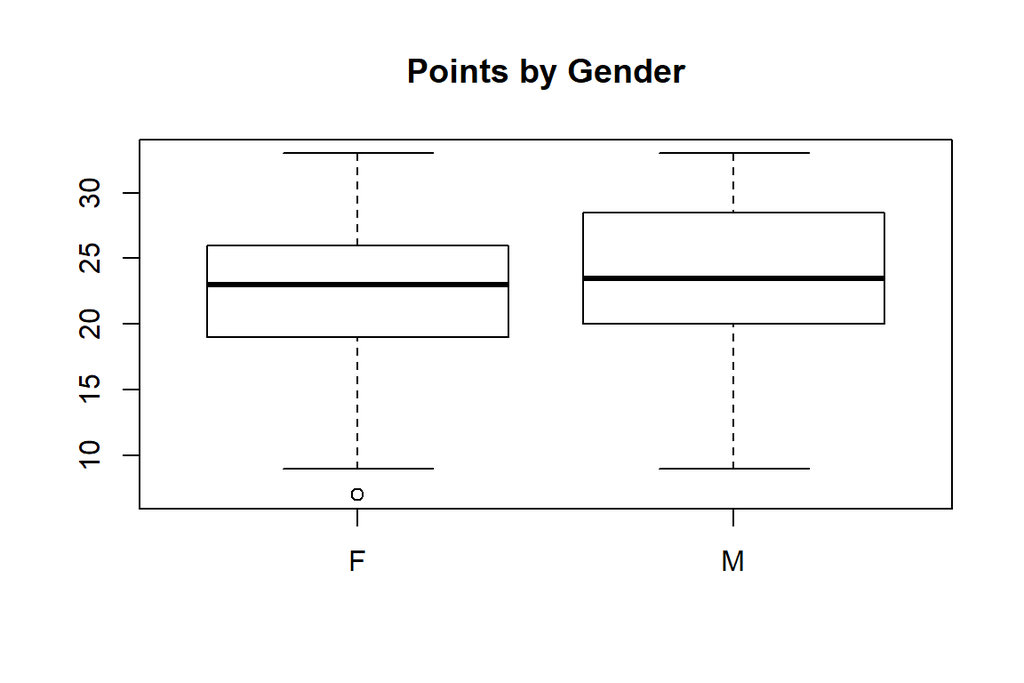

```r
url = "http://s3.amazonaws.com/assets.datacamp.com/production/course_2218/datasets/learning2014.txt"
data_stud <- read.delim(url, sep=",")
boxplot(split(data_stud$points,data_stud$gender),main='Points by Gender')
```

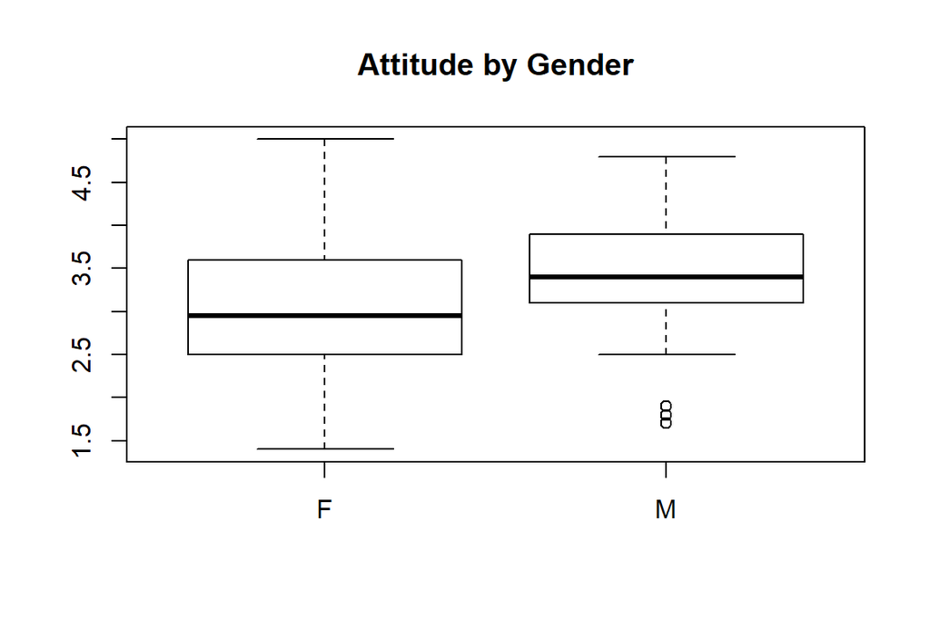

```r
boxplot(split(data_stud$attitude,data_stud$gender),main='Attitude by Gender')
```

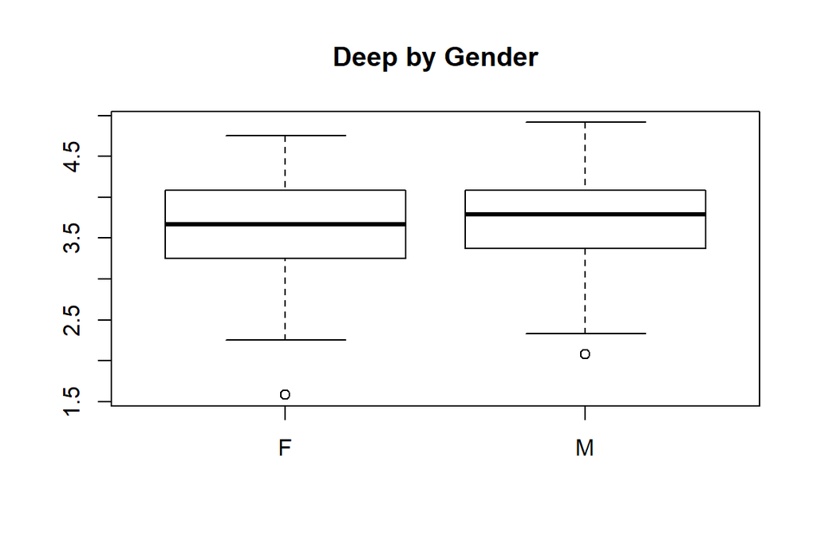

```r
boxplot(split(data_stud$deep,data_stud$gender),main='Deep by Gender')
```

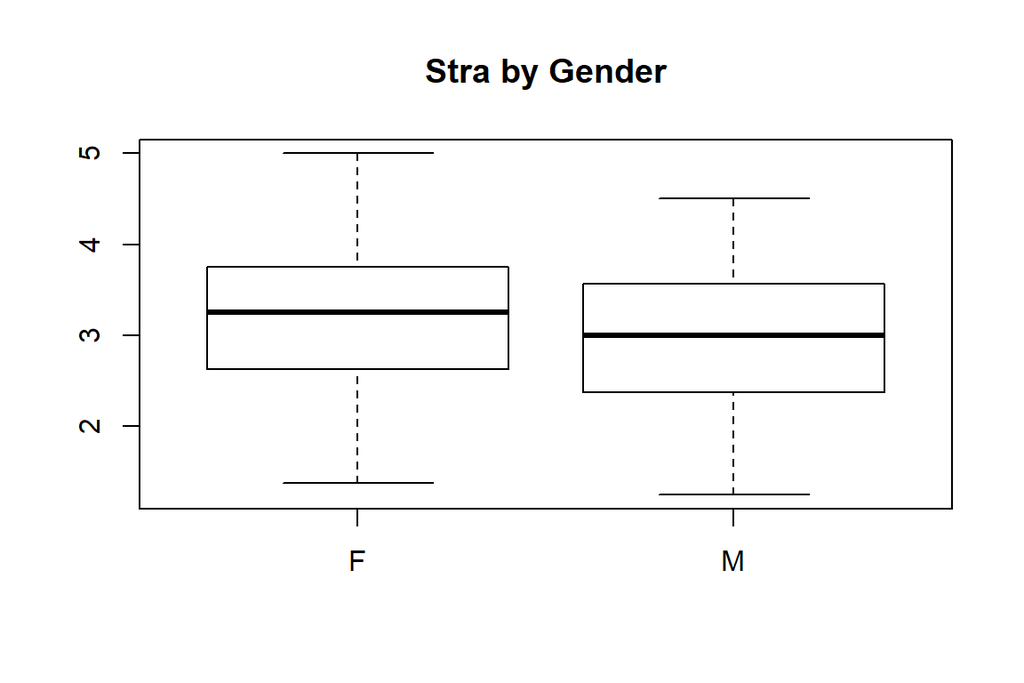

```r
boxplot(split(data_stud$stra,data_stud$gender),main='Stra by Gender')
```

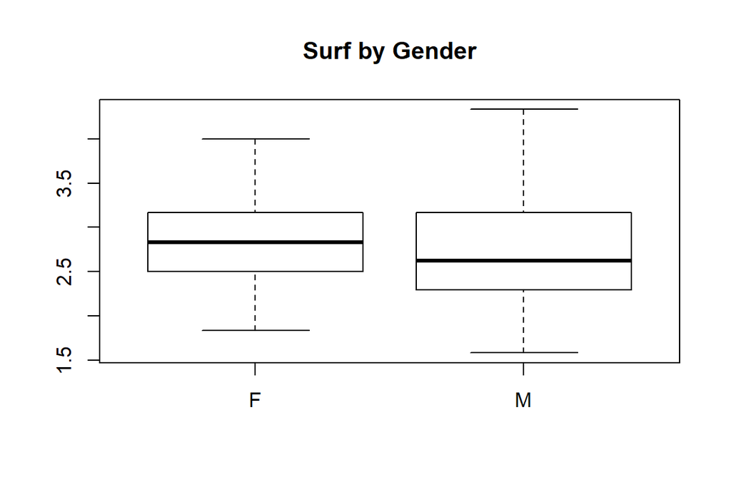

```r
boxplot(split(data_stud$surf,data_stud$gender),main='Surf by Gender')
```

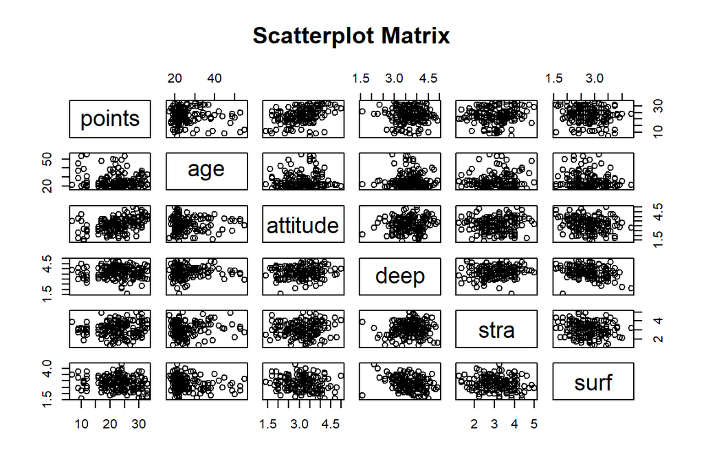

```r
pairs(~points+age+attitude+deep+stra+surf,data=data_stud,
   main="Scatterplot Matrix")
```

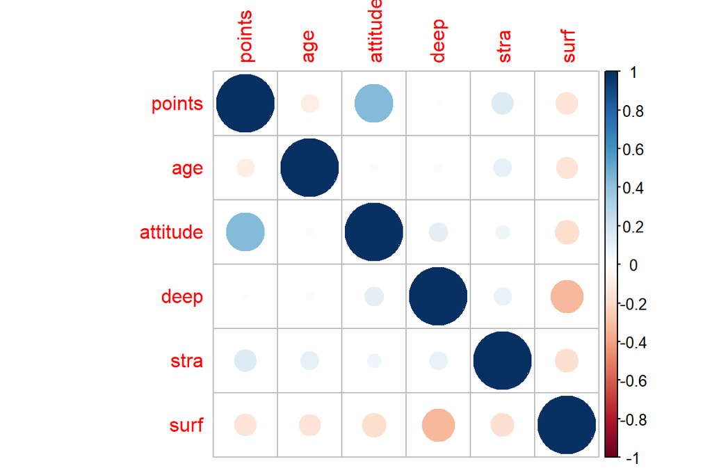

```r
library(corrplot)
data_stud$gender <- factor(data_stud$gender)
num_data <- data_stud[,c("points","age","attitude","deep","stra","surf")]
res <- cor(num_data)
corrplot(as.matrix(res), method="circle")
```

## Comments on data

### Gender

There seems to be slight variation in points between the genders:

```r
url = "http://s3.amazonaws.com/assets.datacamp.com/production/course_2218/datasets/learning2014.txt"
data_stud <- read.delim(url, sep=",")
tapply(data_stud$points, data_stud$gender, mean)
```

```
##        F        M
## 22.32727 23.48214
```

Difference in mean points is (23.48214-22.32727) = 1.16

**Conclusion:** males tend to get slightly higher points than women.

Interesting feature between genders is that especially in attitude-variable (which describes general attitude towards statistics) is higher in males than females. Females on the other hand, are higher at stra (strategic approach: organizing studies and time management). Females might find lack of purpose in statistic related studies and studying it might include unrealted memorising because of it (Surf).

### Age

When looking at age-variable, one should note that there is extremely high number of occurences 20-30-years category: it might give us bad image from how age truly affects the total points of student.

Correlation between points and age:

```r
url = "http://s3.amazonaws.com/assets.datacamp.com/production/course_2218/datasets/learning2014.txt"
data_stud <- read.delim(url, sep=",")
with(data_stud, cor(age, points))
```

```
## [1] -0.09319032
```

Correlation is negative.

**Conclusion:** older the student is - lower the points are. Although, correlation is not particularly strong.

### Attitude, Stra, Deep and Surf

Correlations between students attitude and study habits, and exam points.

```r
url = "http://s3.amazonaws.com/assets.datacamp.com/production/course_2218/datasets/learning2014.txt"
data_stud <- read.delim(url, sep=",")
with(data_stud, cor(attitude, points))
```

```
## [1] 0.4365245
```

```r
with(data_stud, cor(stra, points))
```

```
## [1] 0.1461225
```

```r
with(data_stud, cor(deep, points))
```

```
## [1] -0.01014849
```

```r
with(data_stud, cor(surf, points))
```

```
## [1] -0.1443564
```

The best variable which indicates students points is, by far, **attitude**. Correlation is 0.44.

Stra and Surf are give second best interpretiations: Students with strategic approach tend to get better points, on the other hand Surf decreases students points (Lack of Purpose, Unrelated Memorising, Syllabus-boundness).

## Correlations between the descriptive variables

From correlation plot (with circles from red - blue), we are able to notice that Surf and Deep has strong negative correlation. Students that lack motivation, do not seek new ideas or meaning from statistics.

Strategic approach (Stra) correlates positively between all the variables, except Surf.

*Describe the work you have done this week and summarize your learning.*

- Describe your work and results clearly.
- Assume the reader has an introductory course level understanding of writing and reading R code as well as statistical methods
- Assume the reader has no previous knowledge of your data or the more advanced methods you are using

# Fitting regression model

## Model parameters

I chose three explanatory variables which are:

- Attitude
- Stra
- Age

```r
url = "http://s3.amazonaws.com/assets.datacamp.com/production/course_2218/datasets/learning2014.txt"
l_model <- lm(points ~ attitude + stra + age, data=data_stud)
summary(l_model)
```

```
##
## Call:
## lm(formula = points ~ attitude + stra + age, data = data_stud)
##
## Residuals:
##      Min       1Q   Median       3Q      Max
## -18.1149  -3.2003   0.3303   3.4129  10.7599
##
## Coefficients:
##             Estimate Std. Error t value Pr(>|t|)
## (Intercept) 10.89543    2.64834   4.114 6.17e-05 ***
## attitude     3.48077    0.56220   6.191 4.72e-09 ***
## stra         1.00371    0.53434   1.878   0.0621 .
## age         -0.08822    0.05302  -1.664   0.0981 .
## ---
## Signif. codes:  0 '***' 0.001 '**' 0.01 '*' 0.05 '.' 0.1 ' ' 1
##
## Residual standard error: 5.26 on 162 degrees of freedom
## Multiple R-squared:  0.2182, Adjusted R-squared:  0.2037
## F-statistic: 15.07 on 3 and 162 DF,  p-value: 1.07e-08
```

### What it does?

Multiple linear regression explains the relationship between descriptive variables (attitude, stra, age) and response variables (points). Model fits linear (linear line, bluntly) equation to observed data.

### Results

Although, some of the explanatory variables show statistical significance in linear model, the R-squared value of the whole model stays rather low: 0.20.

Model: Points_est = 10.89543 + (3.48077*attitude) + (1.00371*stra) - (0.08822*age)

### Re-model, without age

```r
url = "http://s3.amazonaws.com/assets.datacamp.com/production/course_2218/datasets/learning2014.txt"
l_model <- lm(points ~ attitude + stra, data=data_stud)
summary(l_model)
```

```
##
## Call:
## lm(formula = points ~ attitude + stra, data = data_stud)
##
## Residuals:
##      Min       1Q   Median       3Q      Max
## -17.6436  -3.3113   0.5575   3.7928  10.9295
##
## Coefficients:
##             Estimate Std. Error t value Pr(>|t|)
## (Intercept)   8.9729     2.3959   3.745  0.00025 ***
## attitude      3.4658     0.5652   6.132 6.31e-09 ***
## stra          0.9137     0.5345   1.709  0.08927 .
## ---
## Signif. codes:  0 '***' 0.001 '**' 0.01 '*' 0.05 '.' 0.1 ' ' 1
##
## Residual standard error: 5.289 on 163 degrees of freedom
## Multiple R-squared:  0.2048, Adjusted R-squared:  0.1951
## F-statistic: 20.99 on 2 and 163 DF,  p-value: 7.734e-09
```

### Results without age

Model got worse without age-variable. R-squared in new model 0.19. Conclusion: continue with attitude, stra and age.

## Diagnostic plots

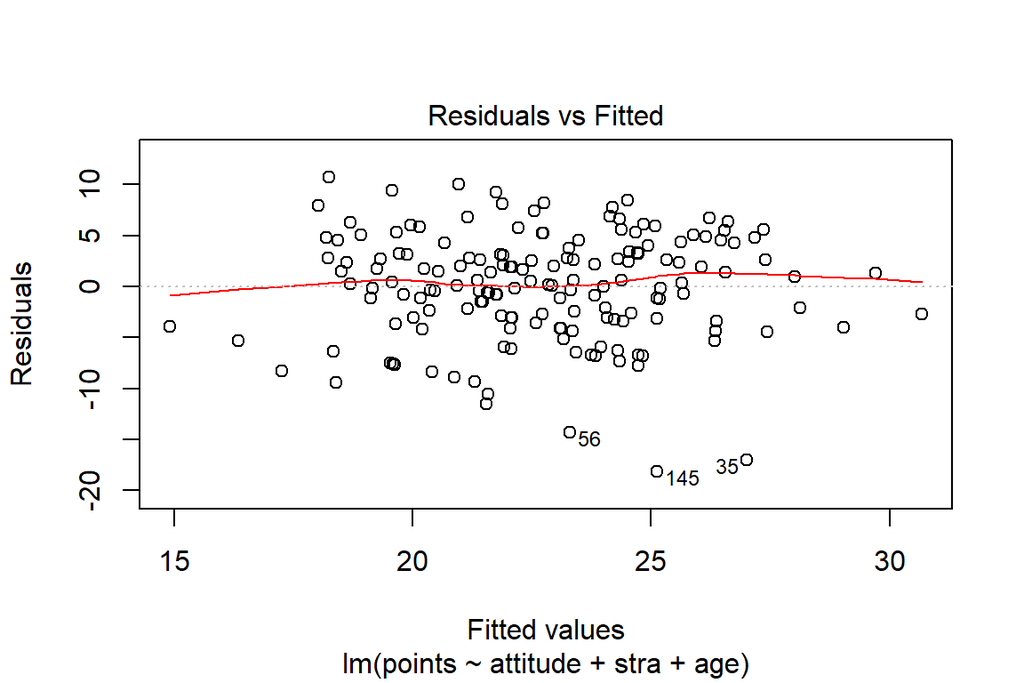

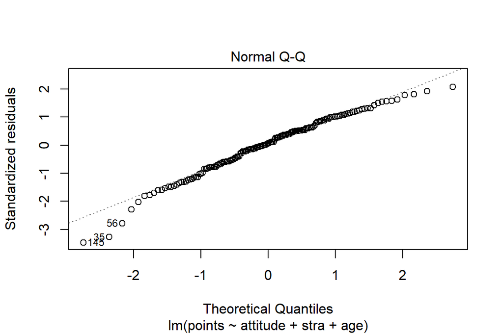

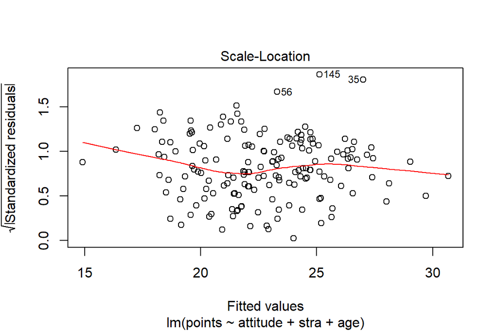

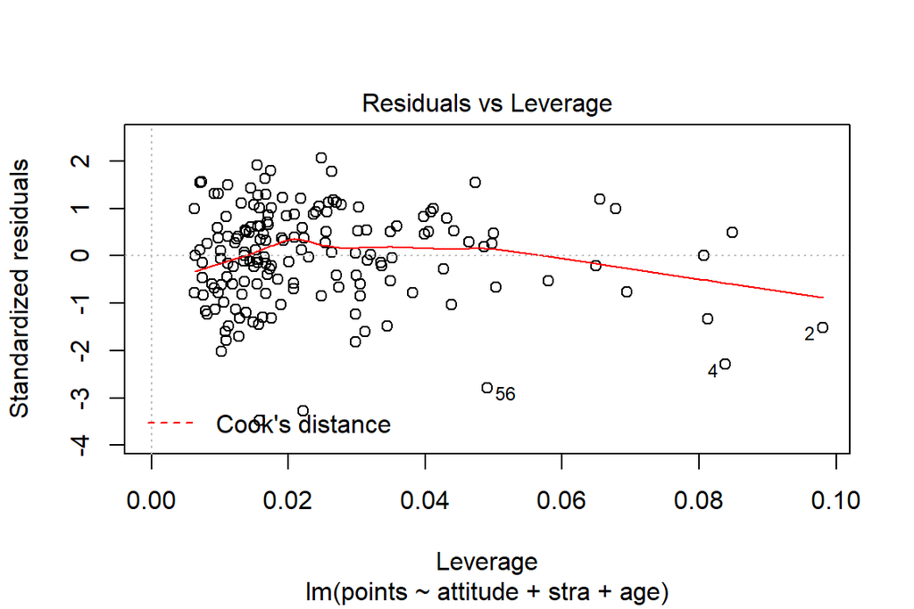

```r
url = "http://s3.amazonaws.com/assets.datacamp.com/production/course_2218/datasets/learning2014.txt"
l_model <- lm(points ~ attitude + stra + age, data=data_stud)
plot(l_model)
```

## Diagnostics interpretation

**Aim** of the diagnostics plots is to explain how well our multilinear model is actually fitting the data.

### Residuals vs Fitted

Scatterplot represents the correlation between model residuals and predicted values. If residuals are small, the model predicts well. On the other hand, if the scatterplot seems sparse, it indicates that model is not giving good predictions. Remember, out model R^2 was only 0.2.

### QQ-plot

Normal Q-Q-plot is a normal probability plot: if errors in model follow normal distribution, line is straight. In our case, there seems to be slight divergence from normal distribution in both ends. Extremely low and high points are harder to predict with the model.

### Residuals vs Leverage

Last plot describes the influence of observations in the model. We can interpret from the plot that obs. 56, 4 and 2 have the most influence to our model. We could go back to the original data and check is there something wrong with it, or make conclusion why these particular students have such a different point - attitude - stra - and age combinations. They are not clearly following the trend.

# Logistic regression analysis

## Data description

Data has 382 observations (students) and 35 variables. Hence, data is a table with 382 rows and 35 columns.

## Variable-names and summary

Data describes students achievement in two Portuguese schools. Attributes give information from student’s social status and studying habits. Although, there are also several variables which describe students overall living habits and morality. Data has been provided regarding the student performance in subjects: Mathematics (mat) and Portuguese language (por).

Article: P. Cortez and A. Silva. Using Data Mining to Predict Secondary School Student Performance. In A. Brito and J. Teixeira Eds., Proceedings of 5th FUture BUsiness TEChnology Conference (FUBUTEC 2008) pp. 5-12, Porto, Portugal, April, 2008, EUROSIS, ISBN 978-9077381-39-7.

```r
url = "http://s3.amazonaws.com/assets.datacamp.com/production/course_2218/datasets/alc.txt"
alc_data <- read.delim(url, sep=",")
summary(alc_data)
```

```
##  school   sex          age        address famsize   Pstatus
##  GP:342   F:198   Min.   :15.00   R: 81   GT3:278   A: 38
##  MS: 40   M:184   1st Qu.:16.00   U:301   LE3:104   T:344
##                   Median :17.00
##                   Mean   :16.59
##                   3rd Qu.:17.00
##                   Max.   :22.00
##       Medu            Fedu             Mjob           Fjob
##  Min.   :0.000   Min.   :0.000   at_home : 53   at_home : 16
##  1st Qu.:2.000   1st Qu.:2.000   health  : 33   health  : 17
##  Median :3.000   Median :3.000   other   :138   other   :211
##  Mean   :2.806   Mean   :2.565   services: 96   services:107
##  3rd Qu.:4.000   3rd Qu.:4.000   teacher : 62   teacher : 31
##  Max.   :4.000   Max.   :4.000
##         reason    nursery   internet    guardian     traveltime
##  course    :140   no : 72   no : 58   father: 91   Min.   :1.000
##  home      :110   yes:310   yes:324   mother:275   1st Qu.:1.000
##  other     : 34                       other : 16   Median :1.000
##  reputation: 98                                    Mean   :1.442
##                                                    3rd Qu.:2.000
##                                                    Max.   :4.000
##    studytime        failures      schoolsup famsup     paid     activities
##  Min.   :1.000   Min.   :0.0000   no :331   no :144   no :205   no :181
##  1st Qu.:1.000   1st Qu.:0.0000   yes: 51   yes:238   yes:177   yes:201
##  Median :2.000   Median :0.0000
##  Mean   :2.034   Mean   :0.2906
##  3rd Qu.:2.000   3rd Qu.:0.0000
##  Max.   :4.000   Max.   :3.0000
##  higher    romantic      famrel        freetime         goout
##  no : 18   no :261   Min.   :1.00   Min.   :1.000   Min.   :1.000
##  yes:364   yes:121   1st Qu.:4.00   1st Qu.:3.000   1st Qu.:2.000
##                      Median :4.00   Median :3.000   Median :3.000
##                      Mean   :3.94   Mean   :3.223   Mean   :3.113
##                      3rd Qu.:5.00   3rd Qu.:4.000   3rd Qu.:4.000
##                      Max.   :5.00   Max.   :5.000   Max.   :5.000
##       Dalc            Walc          health         absences
##  Min.   :1.000   Min.   :1.00   Min.   :1.000   Min.   : 0.000
##  1st Qu.:1.000   1st Qu.:1.00   1st Qu.:3.000   1st Qu.: 0.000
##  Median :1.000   Median :2.00   Median :4.000   Median : 3.000
##  Mean   :1.474   Mean   :2.28   Mean   :3.579   Mean   : 5.319
##  3rd Qu.:2.000   3rd Qu.:3.00   3rd Qu.:5.000   3rd Qu.: 8.000
##  Max.   :5.000   Max.   :5.00   Max.   :5.000   Max.   :75.000
##        G1              G2              G3           alc_use
##  Min.   : 3.00   Min.   : 0.00   Min.   : 0.00   Min.   :1.000
##  1st Qu.: 8.00   1st Qu.: 8.25   1st Qu.: 8.00   1st Qu.:1.000
##  Median :10.50   Median :11.00   Median :11.00   Median :1.500
##  Mean   :10.86   Mean   :10.71   Mean   :10.39   Mean   :1.877
##  3rd Qu.:13.00   3rd Qu.:13.00   3rd Qu.:14.00   3rd Qu.:2.500
##  Max.   :19.00   Max.   :19.00   Max.   :20.00   Max.   :5.000
##   high_use
##  Mode :logical
##  FALSE:270
##  TRUE :112
##
##
##
```

## Choice of four interesting data variables

**1.** Sex - student’s sex (binary: ‘F’ - female or ‘M’ - male)

It’s well-known, that males tend to drink more alcohol than women (especially in “macho-cultures”). **Hypothesis:** Alcohol consumption is generally higher in “M”-class, thus **being male increases the odds to use high amounts of alcohol**.

**2.** Studytime - weekly study time (numeric: 1 - <2 hours, 2 - 2 to 5 hours, 3 - 5 to 10 hours, or 4 - >10 hours)

Students, who are willing to study and work hard, do not generally have time for drinking. Drinking alcohol decreases the students moral to study. **Hypothesis:**: Alcohol consumption decreases when studytime rises. **High studytime decreases the odds to alcohol consumption.**

**3.** Fjob - father’s job (nominal: ‘teacher’, ‘health’ care related, civil ‘services’ (e.g. administrative or police), ‘at_home’ or ‘other’)

I suggest, that father’s job and social status has strong correlation between childrens achievements. Father’s alcohol consumption might have even clearer correlation between students drinking habits: child learns from example! **Hypothesis:** As the fathers social status gets higher, less the children are drinking and getting other bad habits. **Father’s job decreases the students odds to high alcohol consumption**.

**4**. Higher - wants to take higher education (binary: yes or no)

When students are ambitious with their studies, they are less likely spending their time drinking alcohol. **Hypothesis: answering “yes” in this variable decreases the odds to drinking alcohol**.

## Data visualization

### Attiributes overview

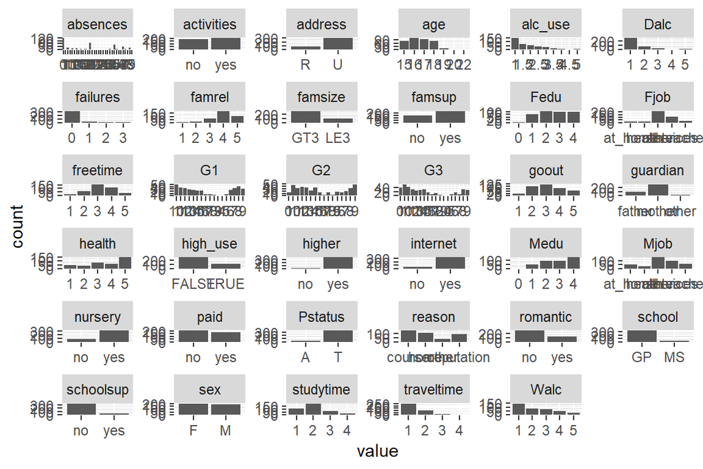

```r
url = "http://s3.amazonaws.com/assets.datacamp.com/production/course_2218/datasets/alc.txt"
alc_data <- read.delim(url, sep=",")
library(tidyr); library(dplyr); library(ggplot2)
gather(alc_data) %>% ggplot(aes(value)) + facet_wrap("key", scales = "free")+ geom_bar()
```

### Choise of variables: Sex

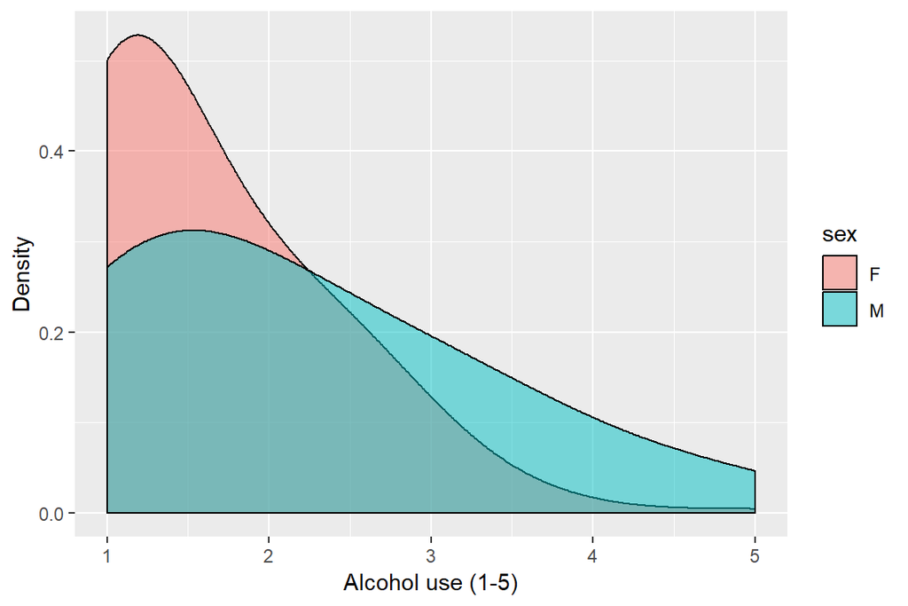

```r
url = "http://s3.amazonaws.com/assets.datacamp.com/production/course_2218/datasets/alc.txt"
alc_data <- read.delim(url, sep=",")
library(tidyr); library(dplyr); library(ggplot2)
ggplot() +
  geom_density(data=alc_data, aes(x=alc_use, group=sex, fill=sex),alpha=0.5, adjust=2) +
  xlab("Alcohol use (1-5)") +
  ylab("Density")
```

### Crosstab

```r
url = "http://s3.amazonaws.com/assets.datacamp.com/production/course_2218/datasets/alc.txt"
alc_data <- read.delim(url, sep=",")
alc_data$sex <- factor(alc_data$sex)
library(tidyr); library(dplyr); library(ggplot2); library(descr)
CrossTable(alc_data$high_use, alc_data$sex)
```

```
##    Cell Contents
## |-------------------------|
## |                       N |
## | Chi-square contribution |
## |           N / Row Total |
## |           N / Col Total |
## |         N / Table Total |
## |-------------------------|
##
## ==========================================
##                      alc_data$sex
## alc_data$high_use        F       M   Total
## ------------------------------------------
## FALSE                  157     113     270
##                      2.078   2.236
##                      0.581   0.419   0.707
##                      0.793   0.614
##                      0.411   0.296
## ------------------------------------------
## TRUE                    41      71     112
##                      5.009   5.390
##                      0.366   0.634   0.293
##                      0.207   0.386
##                      0.107   0.186
## ------------------------------------------
## Total                  198     184     382
##                      0.518   0.482
## ==========================================
```

There seems to be somewhat clear division in alcohol consumption between males and females.Females alcohol consumption is focused on classes 1 and 2, when males drinking is more divided through all the consumption classes. It seems to be really rare to find a portuguese females who report themselves into alc use classes 4-5.

### Choise of variables: Studytime

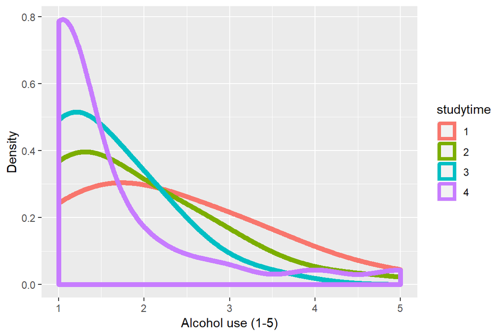

```r
url = "http://s3.amazonaws.com/assets.datacamp.com/production/course_2218/datasets/alc.txt"
alc_data <- read.delim(url, sep=",")
alc_data$studytime <- factor(alc_data$studytime)
library(tidyr); library(dplyr); library(ggplot2)
ggplot() +
  geom_density(data=alc_data, aes(x=alc_use, group=studytime, color=studytime),alpha=1, adjust=2, size=2) +
  xlab("Alcohol use (1-5)") +
  ylab("Density")
```

### Crosstab

```r
url = "http://s3.amazonaws.com/assets.datacamp.com/production/course_2218/datasets/alc.txt"
alc_data <- read.delim(url, sep=",")
alc_data$studytime <- factor(alc_data$studytime)
library(tidyr); library(dplyr); library(ggplot2); library(descr)
CrossTable(alc_data$high_use, alc_data$studytime)
```

```
##    Cell Contents
## |-------------------------|
## |                       N |
## | Chi-square contribution |
## |           N / Row Total |
## |           N / Col Total |
## |         N / Table Total |
## |-------------------------|
##
## ==========================================================
##                      alc_data$studytime
## alc_data$high_use        1       2       3       4   Total
## ----------------------------------------------------------
## FALSE                   60     133      54      23     270
##                      2.251   0.012   2.364   0.804
##                      0.222   0.493   0.200   0.085   0.707
##                      0.583   0.700   0.871   0.852
##                      0.157   0.348   0.141   0.060
## ----------------------------------------------------------
## TRUE                    43      57       8       4     112
##                      5.426   0.030   5.699   1.937
##                      0.384   0.509   0.071   0.036   0.293
##                      0.417   0.300   0.129   0.148
##                      0.113   0.149   0.021   0.010
## ----------------------------------------------------------
## Total                  103     190      62      27     382
##                      0.270   0.497   0.162   0.071
## ==========================================================
```

Studytime has correlation to alcohol consumption: as the studytime rises, the probability to use alcohol decreases. Students who use exceptionally great amounts of time studying (class 3 & 4) seem to be using almost no alcohol, mostly classes 1-2. Fancy thing is, that students who are in studytime class 3 are not participating in heavy drinking (class 5). These people could be described as “middle road walkers”.

### Choise of variables: Father’s job

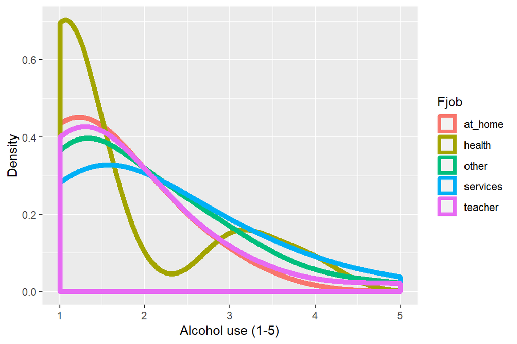

```r
url = "http://s3.amazonaws.com/assets.datacamp.com/production/course_2218/datasets/alc.txt"
alc_data <- read.delim(url, sep=",")
alc_data$Fjob <- factor(alc_data$Fjob)
library(tidyr); library(dplyr); library(ggplot2)
ggplot() +
  geom_density(data=alc_data, aes(x=alc_use, group=Fjob, color=Fjob),alpha=1, adjust=2, size=2) +
  xlab("Alcohol use (1-5)") +
  ylab("Density")
```

### Crosstab

```r
url = "http://s3.amazonaws.com/assets.datacamp.com/production/course_2218/datasets/alc.txt"
alc_data <- read.delim(url, sep=",")
alc_data$Fjob <- factor(alc_data$Fjob)
library(tidyr); library(dplyr); library(ggplot2); library(descr)
CrossTable(alc_data$high_use, alc_data$Fjob)
```

```
##    Cell Contents
## |-------------------------|
## |                       N |
## | Chi-square contribution |
## |           N / Row Total |
## |           N / Col Total |
## |         N / Table Total |
## |-------------------------|
##
## ==========================================================================
##                      alc_data$Fjob
## alc_data$high_use    at_home   health   other   services   teacher   Total
## --------------------------------------------------------------------------
## FALSE                     14       13     149         69        25     270
##                        0.640    0.081   0.000      0.581     0.435
##                        0.052    0.048   0.552      0.256     0.093   0.707
##                        0.875    0.765   0.706      0.645     0.806
##                        0.037    0.034   0.390      0.181     0.065
## --------------------------------------------------------------------------
## TRUE                       2        4      62         38         6     112
##                        1.544    0.194   0.000      1.400     1.050
##                        0.018    0.036   0.554      0.339     0.054   0.293
##                        0.125    0.235   0.294      0.355     0.194
##                        0.005    0.010   0.162      0.099     0.016
## --------------------------------------------------------------------------
## Total                     16       17     211        107        31     382
##                        0.042    0.045   0.552      0.280     0.081
## ==========================================================================
```

Contrary to my earlier hypothesis, father’s job does not seem to have major influence on student’s alcohol consumption. All of the job-classes are divided fairly identical. Interesting feature in father’s job attribute is the “health”-class, which has high altitude in alcohol use 1. On the other hand, there is minor peak in classes 3-4. This could indicate that students whose fathers’ work at ‘health’ care related -jobs tend to use much less alcohol in general, but there are few rebellious students, who stand against their fathers’ health doctrines.

### Choise of variables: Higher education ambitions

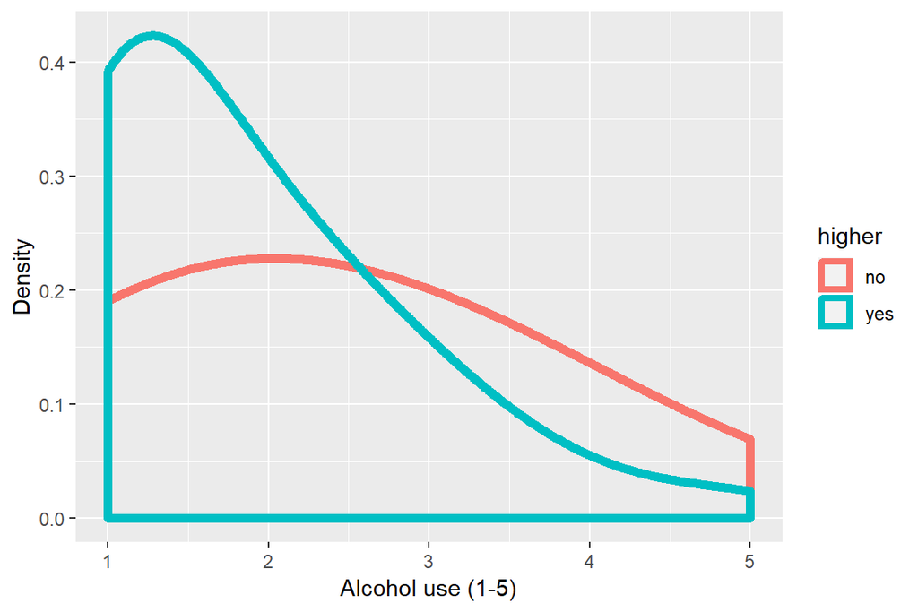

```r
url = "http://s3.amazonaws.com/assets.datacamp.com/production/course_2218/datasets/alc.txt"
alc_data <- read.delim(url, sep=",")
alc_data$higher <- factor(alc_data$higher)
library(tidyr); library(dplyr); library(ggplot2)
ggplot() +
  geom_density(data=alc_data, aes(x=alc_use, group=higher, color=higher),alpha=1, adjust=2, size=2) +
  xlab("Alcohol use (1-5)") +
  ylab("Density")
```

### Crosstab

```r
url = "http://s3.amazonaws.com/assets.datacamp.com/production/course_2218/datasets/alc.txt"
alc_data <- read.delim(url, sep=",")
alc_data$higher <- factor(alc_data$higher)
library(tidyr); library(dplyr); library(ggplot2); library(descr)
CrossTable(alc_data$high_use, alc_data$higher)
```

```
##    Cell Contents
## |-------------------------|
## |                       N |
## | Chi-square contribution |
## |           N / Row Total |
## |           N / Col Total |
## |         N / Table Total |
## |-------------------------|
##
## ==========================================
##                      alc_data$higher
## alc_data$high_use       no     yes   Total
## ------------------------------------------
## FALSE                    9     261     270
##                      1.089   0.054
##                      0.033   0.967   0.707
##                      0.500   0.717
##                      0.024   0.683
## ------------------------------------------
## TRUE                     9     103     112
##                      2.626   0.130
##                      0.080   0.920   0.293
##                      0.500   0.283
##                      0.024   0.270
## ------------------------------------------
## Total                   18     364     382
##                      0.047   0.953
## ==========================================
```

Students ambitions for higher education, does indeed seem to have slight influence on students drinking habits: Higher education seem to attract students who are not using alcohol as much as students who do not have motivation for higher education. Alc. use distribution inside group: “no”, is quite incoherent, and divided more evenly than group: “yes”. It seems that there are students who do not use alcohol but do not either have plans for higher education.

## Logistic model

Logistic regression is traditionally used for modelling regression between predictors (continuous, categorical or a mix of both) and categorical variable, y, which is binary (0/1). Model describes the probability (or odds) for variable “y”, to get value = “1”, with set of predictors. In our case, we are modelling the probability for student to have high alcohol consumption (1), with predictors: sex, studytime, father’s job and ambition for higher education.

### Training & Test datasets

Before applying logistic regression model, we need to split the data into training and testing data. I decided to choose first 300 students as training set for the model. Thus, 82 reimaining students are left for testing the model.

```r
url = "http://s3.amazonaws.com/assets.datacamp.com/production/course_2218/datasets/alc.txt"
alc_data <- read.delim(url, sep=",")
train <- alc_data[1:300,]
test <- alc_data[301:382,]
```

trainset = [1] 300 35

testset = [1] 82 35

### Building model

```r
url = "http://s3.amazonaws.com/assets.datacamp.com/production/course_2218/datasets/alc.txt"
alc_data <- read.delim(url, sep=",")
train <- alc_data[1:300,]
train$sex <- factor(train$sex)
train$studytime <- factor(train$studytime)
train$Fjob <- factor(train$Fjob)
train$higher <- factor(train$higher)
train$high_use <- factor(train$high_use)
model <- glm(high_use ~ sex + studytime + Fjob + higher,family=binomial(link='logit'),data=train)
summary(model)
```

```
##
## Call:
## glm(formula = high_use ~ sex + studytime + Fjob + higher, family = binomial(link = "logit"),
##     data = train)
##
## Deviance Residuals:
##     Min       1Q   Median       3Q      Max
## -1.2661  -0.9208  -0.6262   1.0912   2.2832
##
## Coefficients:
##              Estimate Std. Error z value Pr(>|z|)
## (Intercept)   -1.8926     1.2056  -1.570  0.11645
## sexM           0.5782     0.2841   2.035  0.04183 *
## studytime2    -0.2667     0.3023  -0.882  0.37766
## studytime3    -1.7878     0.6629  -2.697  0.00699 **
## studytime4    -1.4421     0.6781  -2.127  0.03344 *
## Fjobhealth     1.4410     1.2415   1.161  0.24576
## Fjobother      1.2687     1.0925   1.161  0.24551
## Fjobservices   1.8110     1.1074   1.635  0.10199
## Fjobteacher    0.3926     1.2103   0.324  0.74566
## higheryes     -0.2904     0.5513  -0.527  0.59834
## ---
## Signif. codes:  0 '***' 0.001 '**' 0.01 '*' 0.05 '.' 0.1 ' ' 1
##
## (Dispersion parameter for binomial family taken to be 1)
##
##     Null deviance: 361.29  on 299  degrees of freedom
## Residual deviance: 329.60  on 290  degrees of freedom
## AIC: 349.6
##
## Number of Fisher Scoring iterations: 5
```

### Summary of the model

From logistic model summary-table we are able to recognize that predictors: sex and studytime have statistical significance in the model. Although, studytime has significance only inside two of it’s terms (3 and 4).

**Studytime:** Increasing studytime does indeed lower your odds to have bad drinking habits: however, studytime truly begins to decrease odds when student moves from term 2 to term 3. To put it simple, **students who study 5 to 10 hours or more on weekly basis, have considerably smaller odds to have high alcohol use.** Studytime 3 p-value is 0.00699 (lowest value in the model) and correspondingly studytime 4, 0.03344.

**Pursue for higher education:** No statistical significance, but having ambition for higher education lowers the odds for high alcohol use by -0.29.

### Anova-table and McFadden R2 -index

```r
url = "http://s3.amazonaws.com/assets.datacamp.com/production/course_2218/datasets/alc.txt"
alc_data <- read.delim(url, sep=",")
train <- alc_data[1:300,]
train$sex <- factor(train$sex)
train$studytime <- factor(train$studytime)
train$Fjob <- factor(train$Fjob)
train$higher <- factor(train$higher)
train$high_use <- factor(train$high_use)
model <- glm(high_use ~ sex + studytime + Fjob + higher,family=binomial(link='logit'),data=train)

anova(model)
```

```
## Analysis of Deviance Table
##
## Model: binomial, link: logit
##
## Response: high_use
##
## Terms added sequentially (first to last)
##
##
##           Df Deviance Resid. Df Resid. Dev
## NULL                        299     361.29
## sex        1   8.4311       298     352.86
## studytime  3  13.9372       295     338.92
## Fjob       4   9.0447       291     329.88
## higher     1   0.2747       290     329.60
```

```r
library(pscl)
pR2(model)
```

```
##           llh       llhNull            G2      McFadden          r2ML
## -164.80162560 -180.64550478   31.68775835    0.08770702    0.10023878
##          r2CU
##    0.14317798
```

**Anova-table** describes, how well our logistic model predicts high use of alcohol when compared to null-model. Null-model uses only intercept value.

Table shows that, largest difference to deviance comes from studytime. On contrast, students ambitions to higher education, does make small difference to model (0.27).

Furthermore, model fit can be assessed with McFadden’s pseudo R^2-value, which gives only 0.08 for our model.

The difference between the null deviance and the residual deviance shows how our model is doing against the null model (a model with only the intercept).

### Coefficients as odds ratios and confidence intervals

```r
url = "http://s3.amazonaws.com/assets.datacamp.com/production/course_2218/datasets/alc.txt"
alc_data <- read.delim(url, sep=",")
train <- alc_data[1:300,]
train$sex <- factor(train$sex)
train$studytime <- factor(train$studytime)
train$Fjob <- factor(train$Fjob)
train$higher <- factor(train$higher)
train$high_use <- factor(train$high_use)
model <- glm(high_use ~ sex + studytime + Fjob + higher,family=binomial(link='logit'),data=train)
exp(cbind("Odds ratio" = coef(model), confint.default(model, level = 0.95)))
```

```
##              Odds ratio      2.5 %     97.5 %
## (Intercept)   0.1506773 0.01418480  1.6005605
## sexM          1.7829081 1.02160476  3.1115372
## studytime2    0.7658945 0.42348388  1.3851635
## studytime3    0.1673226 0.04563802  0.6134542
## studytime4    0.2364228 0.06258757  0.8930806
## Fjobhealth    4.2250405 0.37072282 48.1517881
## Fjobother     3.5563949 0.41790531 30.2650962
## Fjobservices  6.1164281 0.69798147 53.5984042
## Fjobteacher   1.4807783 0.13814056 15.8729946
## higheryes     0.7479459 0.25386006  2.2036669
```

Table above shows odds ratio of each model predictor. Being male increases the probability to have high alcohol consumption by 1.78. All of the studytime terms (2-4) decrease the odds. Odds ratios are based on asymptonic normality.

# Data clustering and classification

This exercise focuses on how to classify and cluster data into categories according to characteristics of the data. Clustering methods try to find the similarities from the data and on the other what are the attributes which divide data?

## Data overview

```r
library(MASS)
data(Boston)
dim(Boston)
```

```
## [1] 506  14
```

```r
head(Boston)
```

```
##      crim zn indus chas   nox    rm  age    dis rad tax ptratio  black
## 1 0.00632 18  2.31    0 0.538 6.575 65.2 4.0900   1 296    15.3 396.90
## 2 0.02731  0  7.07    0 0.469 6.421 78.9 4.9671   2 242    17.8 396.90
## 3 0.02729  0  7.07    0 0.469 7.185 61.1 4.9671   2 242    17.8 392.83
## 4 0.03237  0  2.18    0 0.458 6.998 45.8 6.0622   3 222    18.7 394.63
## 5 0.06905  0  2.18    0 0.458 7.147 54.2 6.0622   3 222    18.7 396.90
## 6 0.02985  0  2.18    0 0.458 6.430 58.7 6.0622   3 222    18.7 394.12
##   lstat medv
## 1  4.98 24.0
## 2  9.14 21.6
## 3  4.03 34.7
## 4  2.94 33.4
## 5  5.33 36.2
## 6  5.21 28.7
```

“Boston” -dataset describes social and environmental characteristics of Boston city.

**Boston data** has 506 rows (observations) and 14 columns (attributes).

### Variable explanations

- CRIM - per capita crime rate by town
- ZN - proportion of residential land zoned for lots over 25,000 sq.ft.
- INDUS - proportion of non-retail business acres per town.
- CHAS - Charles River dummy variable (1 if tract bounds river; 0 otherwise)
- NOX - nitric oxides concentration (parts per 10 million)
- RM - average number of rooms per dwelling
- AGE - proportion of owner-occupied units built prior to 1940
- DIS - weighted distances to five Boston employment centres
- RAD - index of accessibility to radial highways
- TAX - full-value property-tax rate per $10,000
- PTRATIO - pupil-teacher ratio by town
- B - 1000(Bk - 0.63)^2 where Bk is the proportion of blacks by town
- LSTAT - % lower status of the population
- MEDV - Median value of owner-occupied homes in $1000’s

***Explanations https://www.cs.toronto.edu/~delve/data/boston/bostonDetail.html.***

### Variable visualization

```r
library(MASS); library("GGally")
```

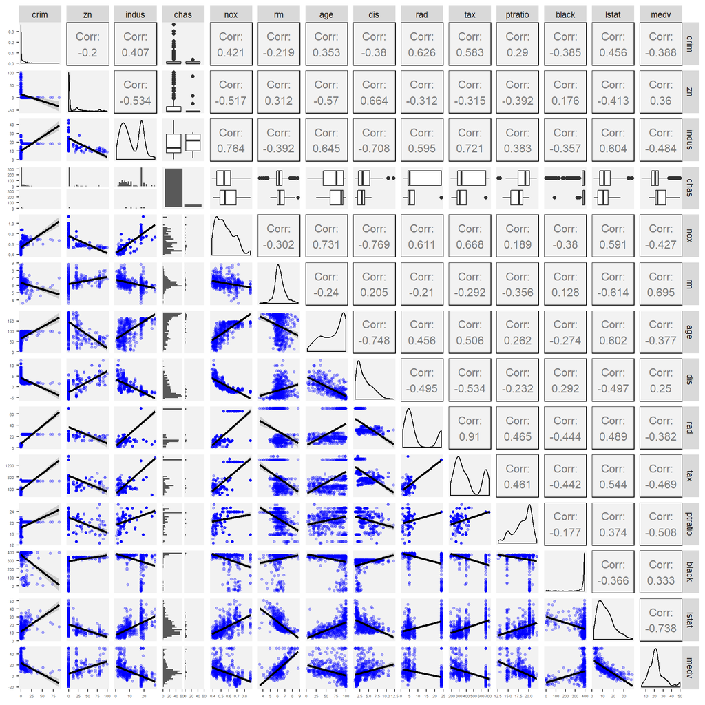

```r
data(Boston)
Boston$chas <- factor(Boston$chas)
lowerFn <- function(data, mapping, ...) {
  p <- ggplot(data = data, mapping = mapping) +
    geom_point(color = 'blue', alpha=0.3, size=1) +
    geom_smooth(color = 'black', method='lm', size=1,...)
  p
}

g <- ggpairs(
  data = Boston,
  lower = list(
    continuous =  wrap(lowerFn) #wrap("smooth", alpha = 0.3, color = "blue", lwd=1)
  ),
  upper = list(continuous = wrap("cor", size = 4))
)
g <- g + theme(
  axis.text = element_text(size = 4),
  axis.title = element_text(size = 4),
  legend.background = element_rect(fill = "white"),
  panel.grid.major = element_line(colour = NA),
  panel.grid.minor = element_blank(),
  panel.background = element_rect(fill = "grey95")
)
print(g, bottomHeightProportion = 0.5, leftWidthProportion = .5)
```

### Summary

```r
library(MASS);
data(Boston)
summary(Boston)
```

```
##       crim                zn             indus            chas
##  Min.   : 0.00632   Min.   :  0.00   Min.   : 0.46   Min.   :0.00000
##  1st Qu.: 0.08204   1st Qu.:  0.00   1st Qu.: 5.19   1st Qu.:0.00000
##  Median : 0.25651   Median :  0.00   Median : 9.69   Median :0.00000
##  Mean   : 3.61352   Mean   : 11.36   Mean   :11.14   Mean   :0.06917
##  3rd Qu.: 3.67708   3rd Qu.: 12.50   3rd Qu.:18.10   3rd Qu.:0.00000
##  Max.   :88.97620   Max.   :100.00   Max.   :27.74   Max.   :1.00000
##       nox               rm             age              dis
##  Min.   :0.3850   Min.   :3.561   Min.   :  2.90   Min.   : 1.130
##  1st Qu.:0.4490   1st Qu.:5.886   1st Qu.: 45.02   1st Qu.: 2.100
##  Median :0.5380   Median :6.208   Median : 77.50   Median : 3.207
##  Mean   :0.5547   Mean   :6.285   Mean   : 68.57   Mean   : 3.795
##  3rd Qu.:0.6240   3rd Qu.:6.623   3rd Qu.: 94.08   3rd Qu.: 5.188
##  Max.   :0.8710   Max.   :8.780   Max.   :100.00   Max.   :12.127
##       rad              tax           ptratio          black
##  Min.   : 1.000   Min.   :187.0   Min.   :12.60   Min.   :  0.32
##  1st Qu.: 4.000   1st Qu.:279.0   1st Qu.:17.40   1st Qu.:375.38
##  Median : 5.000   Median :330.0   Median :19.05   Median :391.44
##  Mean   : 9.549   Mean   :408.2   Mean   :18.46   Mean   :356.67
##  3rd Qu.:24.000   3rd Qu.:666.0   3rd Qu.:20.20   3rd Qu.:396.23
##  Max.   :24.000   Max.   :711.0   Max.   :22.00   Max.   :396.90
##      lstat            medv
##  Min.   : 1.73   Min.   : 5.00
##  1st Qu.: 6.95   1st Qu.:17.02
##  Median :11.36   Median :21.20
##  Mean   :12.65   Mean   :22.53
##  3rd Qu.:16.95   3rd Qu.:25.00
##  Max.   :37.97   Max.   :50.00
```

### Data interpretation

The data consists mainly of continuous variables; only categorical variable is “CHAS” -attribute, which gets binary values (0/1). CHAS equals to 1 if tract bounds Charles River, 0 otherwise. Other variables are ratios and or proportions which describe the city districts: social, economical and environmental factors affecting the price of houses and apartments in Boston. From graphical overview, we are able to recognize several strong correlations between the variables: in this interpretation, I will be discussing only the major trends in the data.

**The strongest correlation** in the data can be found between MEDV (house price) and LSTAT (% lower status of pop.) - correlation of -0.74. As the lower status pop. increases the median housing price decreases rapidly.

**RM (average number of rooms per dwelling) has strong positive correlation (0.70)** with MEDV. This is also pretty obvious correlation - more rooms (and space), more costly housing. **PRATIO has strong negative correlation (-0.51)** with MEDV. PRATIO describes the pupil -teacher ratio by town. Attribute reflects the overall social status in the town: there is often less funds to offer for schools at less popular and poorer parts of city - class-sizes tend to grow. At socially “better” areas there are private schools, which have lower PRATIO.

## Standardizing data

Scale-function standardizes data’s each observation by column average and standard deviatian.

- Scaled_value = value - col_mean / col_std

```r
library(MASS);
data(Boston)
boston_scaled <- scale(Boston)
summary(boston_scaled)
```

```
##       crim                 zn               indus
##  Min.   :-0.419367   Min.   :-0.48724   Min.   :-1.5563
##  1st Qu.:-0.410563   1st Qu.:-0.48724   1st Qu.:-0.8668
##  Median :-0.390280   Median :-0.48724   Median :-0.2109
##  Mean   : 0.000000   Mean   : 0.00000   Mean   : 0.0000
##  3rd Qu.: 0.007389   3rd Qu.: 0.04872   3rd Qu.: 1.0150
##  Max.   : 9.924110   Max.   : 3.80047   Max.   : 2.4202
##       chas              nox                rm               age
##  Min.   :-0.2723   Min.   :-1.4644   Min.   :-3.8764   Min.   :-2.3331
##  1st Qu.:-0.2723   1st Qu.:-0.9121   1st Qu.:-0.5681   1st Qu.:-0.8366
##  Median :-0.2723   Median :-0.1441   Median :-0.1084   Median : 0.3171
##  Mean   : 0.0000   Mean   : 0.0000   Mean   : 0.0000   Mean   : 0.0000
##  3rd Qu.:-0.2723   3rd Qu.: 0.5981   3rd Qu.: 0.4823   3rd Qu.: 0.9059
##  Max.   : 3.6648   Max.   : 2.7296   Max.   : 3.5515   Max.   : 1.1164
##       dis               rad               tax             ptratio
##  Min.   :-1.2658   Min.   :-0.9819   Min.   :-1.3127   Min.   :-2.7047
##  1st Qu.:-0.8049   1st Qu.:-0.6373   1st Qu.:-0.7668   1st Qu.:-0.4876
##  Median :-0.2790   Median :-0.5225   Median :-0.4642   Median : 0.2746
##  Mean   : 0.0000   Mean   : 0.0000   Mean   : 0.0000   Mean   : 0.0000
##  3rd Qu.: 0.6617   3rd Qu.: 1.6596   3rd Qu.: 1.5294   3rd Qu.: 0.8058
##  Max.   : 3.9566   Max.   : 1.6596   Max.   : 1.7964   Max.   : 1.6372
##      black             lstat              medv
##  Min.   :-3.9033   Min.   :-1.5296   Min.   :-1.9063
##  1st Qu.: 0.2049   1st Qu.:-0.7986   1st Qu.:-0.5989
##  Median : 0.3808   Median :-0.1811   Median :-0.1449
##  Mean   : 0.0000   Mean   : 0.0000   Mean   : 0.0000
##  3rd Qu.: 0.4332   3rd Qu.: 0.6024   3rd Qu.: 0.2683
##  Max.   : 0.4406   Max.   : 3.5453   Max.   : 2.9865
```

```r
boston_scaled <- as.data.frame(boston_scaled)
```

From summary we are able to recognize the result of standardization: Min. values in in each variable are negative, since all the values below mean of the column are now below zero. Also, higher the deviation in col. - smaller the min. value is. On the other hand, the max. is higher if there is small deviation in data. Mean value is always 0 in each variable.

### Creating categorical variable from CRIM

```r
library(MASS); library(dplyr, warn.conflicts = FALSE)
data(Boston)
boston_scaled <- scale(Boston)
boston_scaled <- as.data.frame(boston_scaled)
bins <- quantile(boston_scaled$crim)

# create a categorical variable 'crime'
labels <- c("low","med_low","med_high","high")
crime <- cut(boston_scaled$crim, breaks = bins, include.lowest = TRUE, labels = labels)
levels(crime)
```

```
## [1] "low"      "med_low"  "med_high" "high"
```

```r
table(crime)
```

```
## crime
##      low  med_low med_high     high
##      127      126      126      127
```

```r
# remove original crim from the dataset
boston_scaled <- dplyr::select(boston_scaled, -crim)

# add the new categorical value to scaled data
boston_scaled <- data.frame(boston_scaled, crime)
```

In the code above, CRIM -varible has been transformed into categorical (4-levels) using the quantiles of standardized CRIM. We basically divided the data into 4 groups, where first group holds values under the lower quantile (0.25), second group values between lower and mean (0.25-0.5) and so on. I renamed the levels into more appropriate. Since we standardized the data earlier, all the classes have exactly same amount of observations (low and high has 127, because data cant be divided with 4 equally)

## Linear discriminant analysis (training and test-set inc.)

In order to create proper predictative models, we need to split our data into training and testing datasets. In our case, we split our data into training (80 %) and test-sets (20 %) with random sample and remove crime-variable from test-set. Next we fit the data with discriminant analysis where crime is target variable and all the other variables in the dataset as predictor variables. LDA is a data classification method, where we aim to find linear combination of variables which separate target variable classes (crime-levels).

```r
# boston_scaled is available
library(MASS); library(dplyr, warn.conflicts = FALSE)
data(Boston)
boston_scaled <- scale(Boston)
boston_scaled <- as.data.frame(boston_scaled)
bins <- quantile(boston_scaled$crim)
labels <- c("low","med_low","med_high","high")
crime <- cut(boston_scaled$crim, breaks = bins, include.lowest = TRUE, labels = labels)
boston_scaled <- dplyr::select(boston_scaled, -crim)
boston_scaled <- data.frame(boston_scaled, crime)


# number of rows in the Boston dataset
n <- dim(boston_scaled)[1]

# choose randomly 80% of the rows
ind <- sample(n,  size = n * 0.8)

# create train set
train <- boston_scaled[ind,]

# create test set
test <- boston_scaled[-ind,]

# save the correct classes from test data
correct_classes <- test$crime
# remove the crime variable from test data
test <- dplyr::select(test, -crime)


# linear discriminant analysis
lda.fit <- lda(crime ~ ., data = train)

# print the lda.fit object
lda.fit
```

```
## Call:
## lda(crime ~ ., data = train)
##
## Prior probabilities of groups:
##       low   med_low  med_high      high
## 0.2475248 0.2376238 0.2574257 0.2574257
##
## Group means:
##                   zn      indus        chas        nox         rm
## low       1.12837032 -0.9418581 -0.11484506 -0.9181843  0.4982167
## med_low  -0.07834416 -0.2604348  0.01475116 -0.5403260 -0.1279131
## med_high -0.37922279  0.1414272  0.29552193  0.3635062  0.1560378
## high     -0.48724019  1.0149946 -0.12090214  1.0786170 -0.3935284
##                 age        dis        rad        tax    ptratio
## low      -0.9601419  0.9807781 -0.6959029 -0.7404135 -0.4787805
## med_low  -0.3841891  0.2895099 -0.5440181 -0.4195272 -0.0184340
## med_high  0.4492975 -0.3807967 -0.3844475 -0.2993899 -0.3565354
## high      0.8126132 -0.8457577  1.6596029  1.5294129  0.8057784
##                black       lstat         medv
## low       0.38522395 -0.79347632  0.598905223
## med_low   0.34697814 -0.15840618  0.002209247
## med_high  0.08853294  0.03043264  0.221001988
## high     -0.76185296  0.89269941 -0.753803182
##
## Coefficients of linear discriminants:
##                  LD1          LD2        LD3
## zn       0.119434342  0.751200856 -0.8305622
## indus   -0.045880456 -0.199180684  0.1459293
## chas    -0.067461646 -0.093308379  0.0759773
## nox      0.314353556 -0.619975438 -1.2850756
## rm      -0.084560803 -0.060205253 -0.1367151
## age      0.373229686 -0.409852416 -0.3878346
## dis     -0.077777910 -0.257116407 -0.1599710
## rad      3.197155618  0.886839392 -0.3291551
## tax      0.007609037 -0.001500382  0.8555553
## ptratio  0.145265887  0.078983007 -0.1414784
## black   -0.189202608  0.025635437  0.1912432
## lstat    0.170041674 -0.198466695  0.2404606
## medv     0.143526055 -0.351471580 -0.3039959
##
## Proportion of trace:
##    LD1    LD2    LD3
## 0.9458 0.0414 0.0128
```

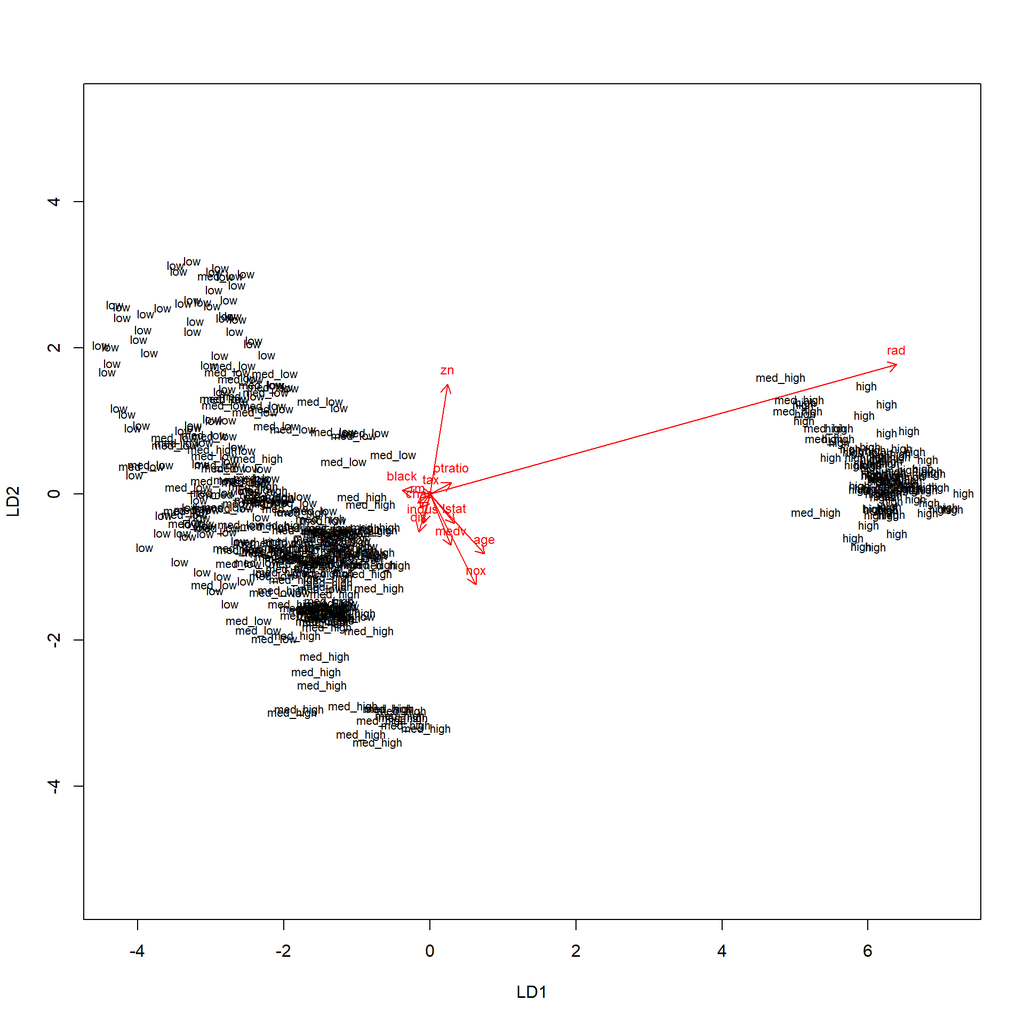

```r
lda.arrows <- function(x, myscale = 1, arrow_heads = 0.1, color = "red", tex = 0.75, choices = c(1,2)){
  heads <- coef(x)
  arrows(x0 = 0, y0 = 0,
         x1 = myscale * heads[,choices[1]],
         y1 = myscale * heads[,choices[2]], col=color, length = arrow_heads)
  text(myscale * heads[,choices], labels = row.names(heads),
       cex = tex, col=color, pos=3)
}
# target classes as numeric
classes <- as.numeric(train$crime)

# plot the lda results
plot(lda.fit, dimen = 2)
lda.arrows(lda.fit, myscale = 2)
```

### LDA predictions

```r
# boston_scaled is available
library(MASS); library(dplyr, warn.conflicts = FALSE)
data(Boston)
boston_scaled <- scale(Boston)
boston_scaled <- as.data.frame(boston_scaled)
bins <- quantile(boston_scaled$crim)
labels <- c("low","med_low","med_high","high")
crime <- cut(boston_scaled$crim, breaks = bins, include.lowest = TRUE, labels = labels)
boston_scaled <- dplyr::select(boston_scaled, -crim)
boston_scaled <- data.frame(boston_scaled, crime)
n <- dim(boston_scaled)[1]
ind <- sample(n,  size = n * 0.8)
train <- boston_scaled[ind,]
test <- boston_scaled[-ind,]
correct_classes <- test$crime
test <- dplyr::select(test, -crime)
lda.fit <- lda(crime ~ ., data = train)
classes <- as.numeric(train$crime)


# predict classes with test data
lda.pred <- predict(lda.fit, newdata = test)

# cross tabulate the results
table(correct = correct_classes, predicted = lda.pred$class)
```

```
##           predicted
## correct    low med_low med_high high
##   low       15       4        1    0
##   med_low    3      15        4    0
##   med_high   0      19       16    2
##   high       0       0        0   23
```

Table above shows that our model is predicting crime-rates fairly well: it seems to predict the lowest and highest proportions really well. On contrary, model struggles with medium classes. Earlier LDA-plot shows that there exists med-low and med-high points near the low- and high -class concentrations. It seems data should be categorized into low/high -classes instead on 4.

### Clustering the data (euclidean dist.)

Calculating imaginary distance between the observations is one method to sort data: in the code I standardize the original data and calculate euclidean distance -matrix and later the manhattan distance -matrix. Matrices has pairwise distances between observations (city districts) and it would be too heavy to summarize properly. I have printed the short, summary-tables with descriptive statistical variables. It seems that manhattan distance (below) has generally longer distances: it’s pretty obvious, since in manhattan distance, we are not choosing the “straight path”. (More from https://www.quora.com/What-is-Manhattan-Distance)

```r
library(MASS); library(dplyr, warn.conflicts = FALSE)
data(Boston)
boston_scaled <- scale(Boston)
boston_scaled <- as.data.frame(boston_scaled)

# euclidean distance matrix
dist_eu <- dist(boston_scaled)

# look at the summary of the distances
summary(dist_eu)
```

```
##    Min. 1st Qu.  Median    Mean 3rd Qu.    Max.
##  0.1343  3.4625  4.8241  4.9111  6.1863 14.3970
```

```r
# manhattan distance matrix
dist_man <- dist(boston_scaled, method ="manhattan")

# look at the summary of the distances
summary(dist_man)
```

```
##    Min. 1st Qu.  Median    Mean 3rd Qu.    Max.
##  0.2662  8.4832 12.6090 13.5488 17.7568 48.8618
```

### Clustering the data (Kmeans, clusters = 4)

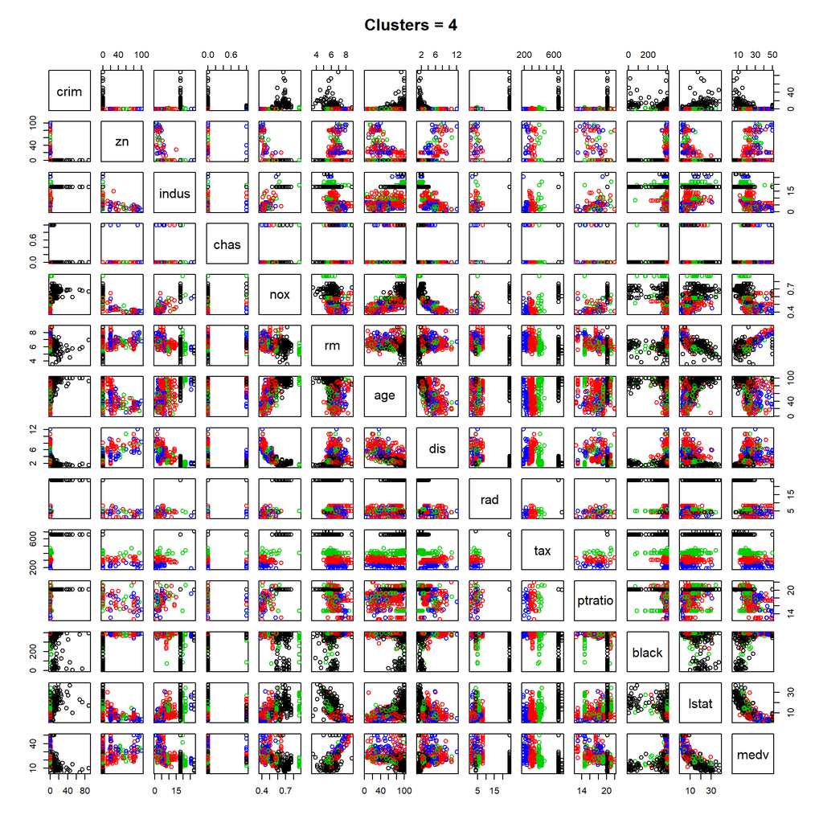

```r
library(MASS); library(dplyr, warn.conflicts = FALSE)
data(Boston)
boston_scaled <- scale(Boston)
boston_scaled <- as.data.frame(boston_scaled)
# k-means clustering
km <-kmeans(Boston, centers = 4)

# plot the Boston dataset with clusters
pairs(Boston, col = km$cluster,main="Clusters = 4")
```

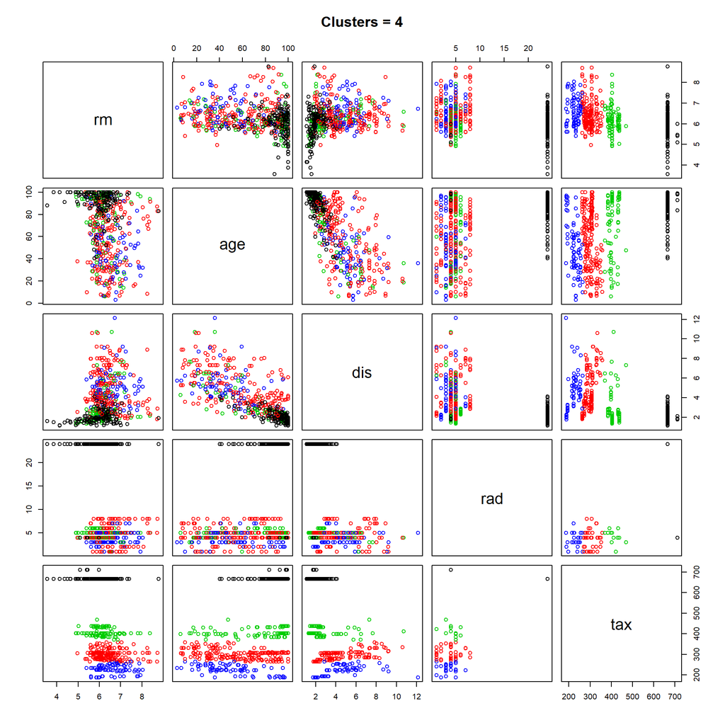

```r
pairs(Boston[6:10], col = km$cluster,main="Clusters = 4")
```

### Clustering the data (Kmeans, clusters = 3, 2)

While observing the pairs-plot, it seems rather clear, that clustering data with four groups is not providing very good results: it looks like in most variables 2 groups would do the trick. Lets try with 3 clusters and then by 2.

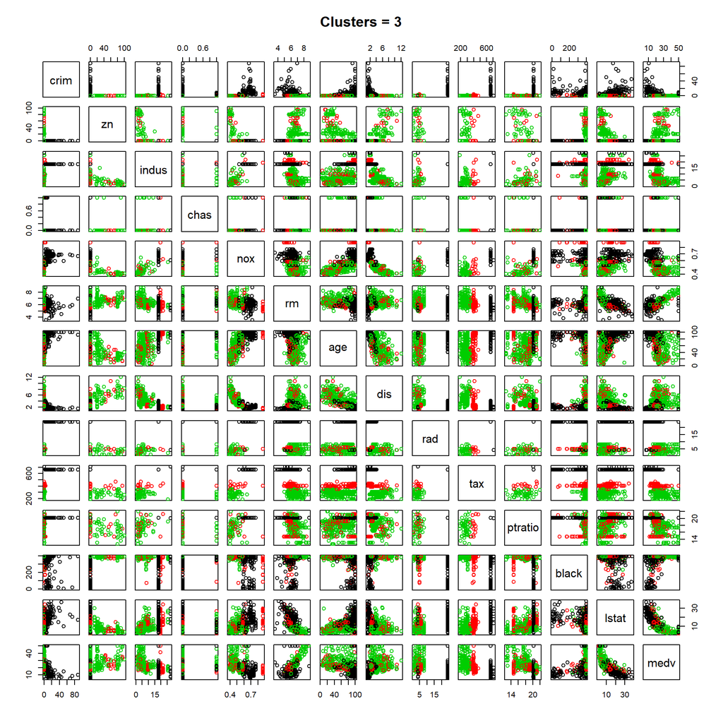

```r
library(MASS); library(dplyr, warn.conflicts = FALSE)
data(Boston)
boston_scaled <- scale(Boston)
boston_scaled <- as.data.frame(boston_scaled)
# k-means clustering
km <-kmeans(Boston, centers = 3)

# plot the Boston dataset with clusters
pairs(Boston, col = km$cluster, main="Clusters = 3")
```

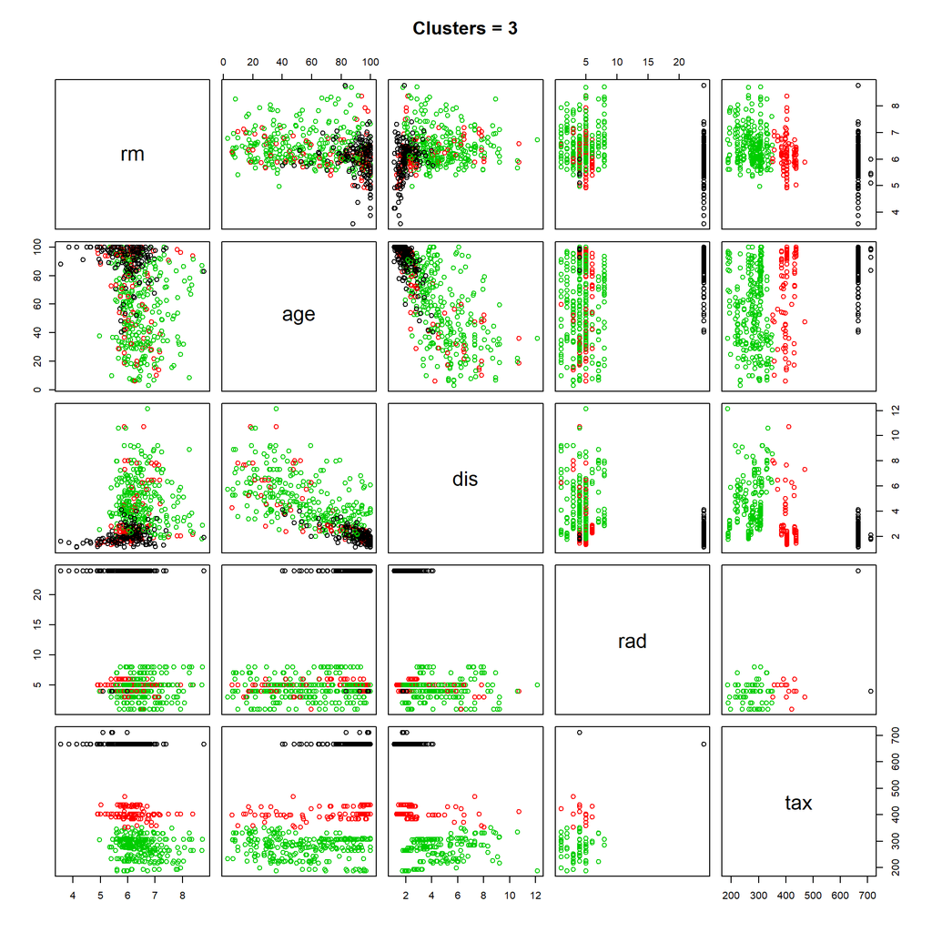

```r
pairs(Boston[6:10], col = km$cluster, main="Clusters = 3")
```

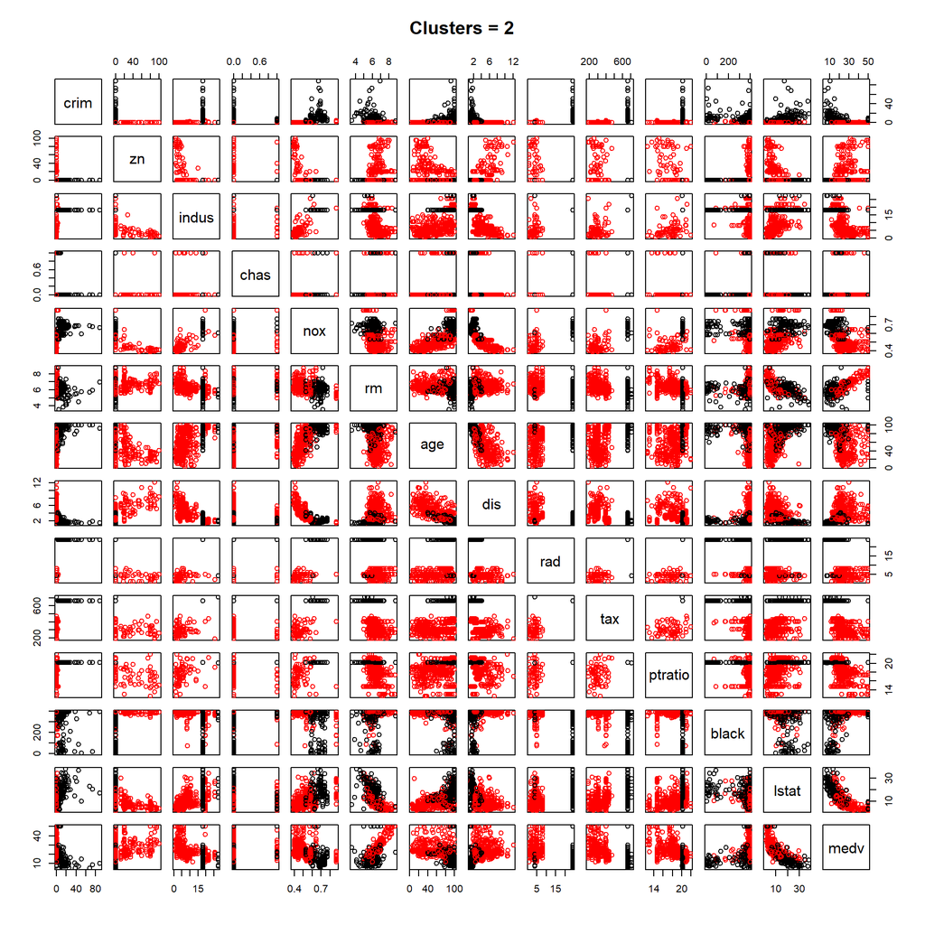

```r
km <-kmeans(Boston, centers = 2)
# plot the Boston dataset with clusters
pairs(Boston, col = km$cluster, main="Clusters = 2")
```

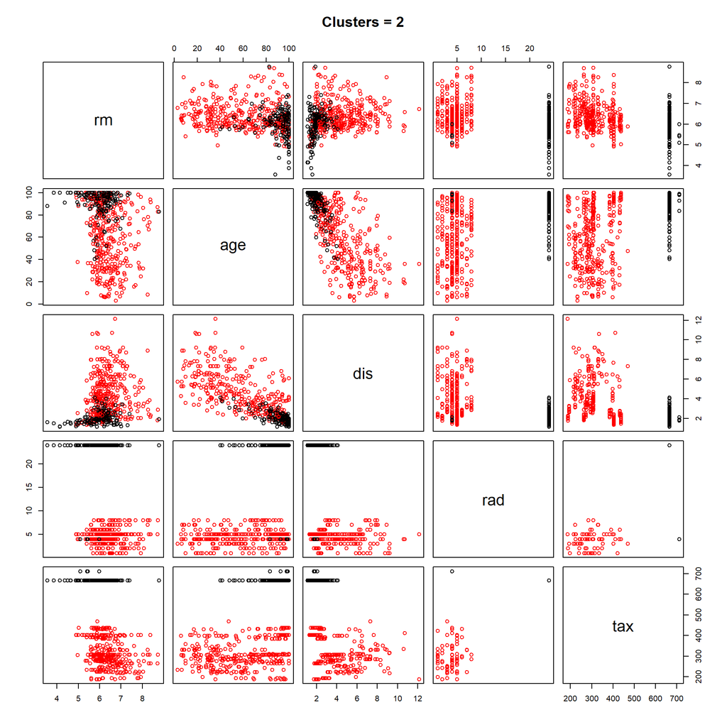

```r
pairs(Boston[6:10], col = km$cluster, main="Clusters = 2")
```

### Finding the optimal number of clusters

For the last part, we will use the within cluster sum of squares (WCSS) to optimize the number of clusters in data. Optimal number is found when the WCSS-value dives in cluster - WCSS -plot. Method produces different solution every time, since function sets it’s “seed-points” randomly.

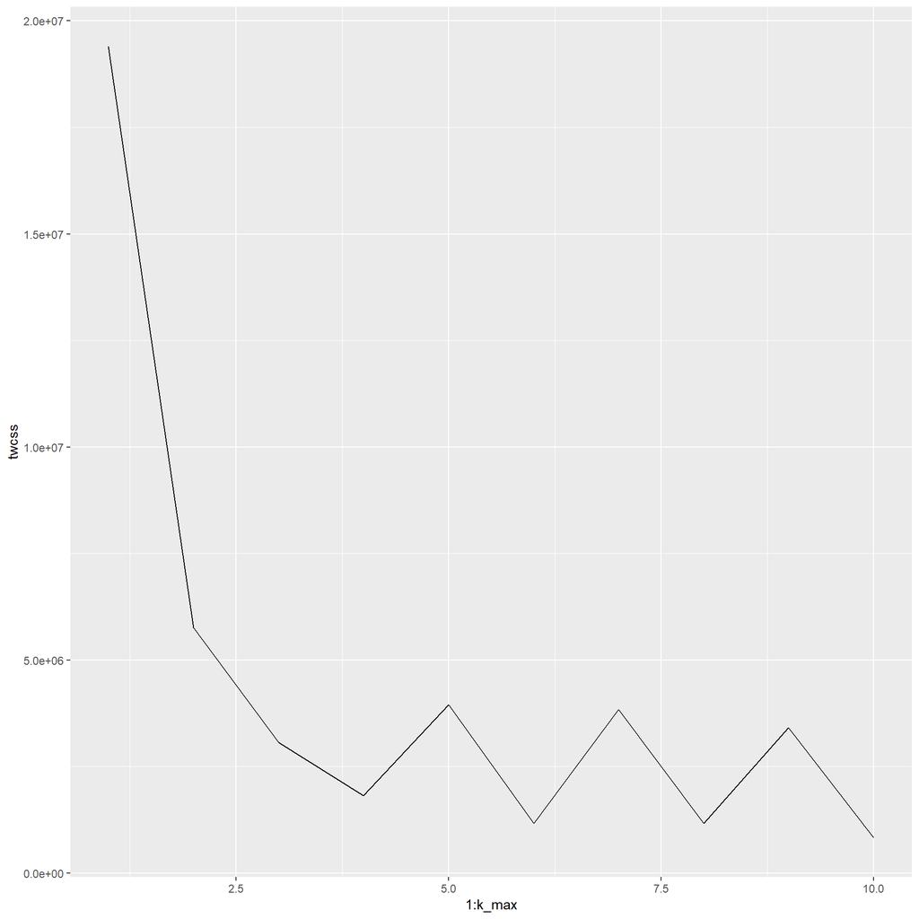

```r
library(MASS); library(dplyr, warn.conflicts = FALSE)
data(Boston)
boston_scaled <- scale(Boston)
boston_scaled <- as.data.frame(boston_scaled)
# MASS, ggplot2 and Boston dataset are available
set.seed(123)

# determine the number of clusters
k_max <- 10

# calculate the total within sum of squares
twcss <- sapply(1:k_max, function(k){kmeans(Boston, k)$tot.withinss})

# visualize the results
qplot(x = 1:k_max, y = twcss, geom = 'line')
```

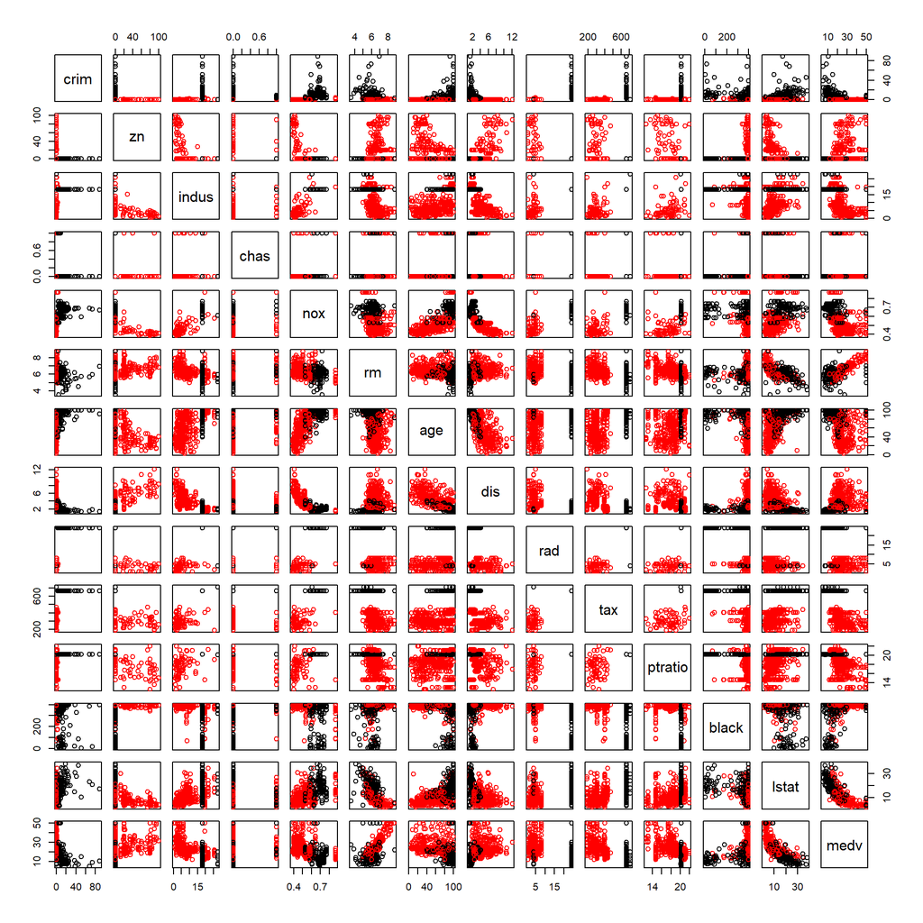

```r
# k-means clustering
km <-kmeans(Boston, centers = 2)

# plot the Boston dataset with clusters
pairs(Boston, col = km$cluster)
```

## Conclusion

### Optimal number of clusters = 2

Cluster-WCSS -plot shows that the optimal number of clusters seems to be at 2. Line takes radical drop at that point, adding clusters does not seem to add value to clustering.

# Dimensionality reduction techniques

Statistical problems are often multidimensional: in order to understand different phenomena, it is necessary to “chop” variables into smaller pieces. This is what dimensionality reduction techniques aims for - we take original data variables and transform them into few components that collect together as much variance as possible from the original data. Thus, components make data interpretation, plotting etc. easier and more informative.

## Data overview

```r
human <- read.table("http://s3.amazonaws.com/assets.datacamp.com/production/course_2218/datasets/human2.txt",sep  =",", header = T)

dim(human)
```

```
## [1] 155   8
```

```r
head(human)
```

```
##               Edu2.FM   Labo.FM Edu.Exp Life.Exp   GNI Mat.Mor Ado.Birth
## Norway      1.0072389 0.8908297    17.5     81.6 64992       4       7.8
## Australia   0.9968288 0.8189415    20.2     82.4 42261       6      12.1
## Switzerland 0.9834369 0.8251001    15.8     83.0 56431       6       1.9
## Denmark     0.9886128 0.8840361    18.7     80.2 44025       5       5.1
## Netherlands 0.9690608 0.8286119    17.9     81.6 45435       6       6.2
## Germany     0.9927835 0.8072289    16.5     80.9 43919       7       3.8
##             Parli.F
## Norway         39.6
## Australia      30.5
## Switzerland    28.5
## Denmark        38.0
## Netherlands    36.9
## Germany        36.9
```

```r
str(human)
```

```
## 'data.frame':    155 obs. of  8 variables:
##  $ Edu2.FM  : num  1.007 0.997 0.983 0.989 0.969 ...
##  $ Labo.FM  : num  0.891 0.819 0.825 0.884 0.829 ...
##  $ Edu.Exp  : num  17.5 20.2 15.8 18.7 17.9 16.5 18.6 16.5 15.9 19.2 ...
##  $ Life.Exp : num  81.6 82.4 83 80.2 81.6 80.9 80.9 79.1 82 81.8 ...
##  $ GNI      : int  64992 42261 56431 44025 45435 43919 39568 52947 42155 32689 ...
##  $ Mat.Mor  : int  4 6 6 5 6 7 9 28 11 8 ...
##  $ Ado.Birth: num  7.8 12.1 1.9 5.1 6.2 3.8 8.2 31 14.5 25.3 ...
##  $ Parli.F  : num  39.6 30.5 28.5 38 36.9 36.9 19.9 19.4 28.2 31.4 ...
```

### Variables

- Edu2.FM (Education index (females))
- Labo.FM (Labour force participation rate (females))
- Edu.Exp (Expected years at schooling)
- Life.Exp (Life expectancy index)
- GNI (Gross national income ($))
- Mat.Mor (Material morality)
- Ado.Birth (Adolescent birth rate)
- Parli.F (Parliamentary representation (females))

### Data visualization

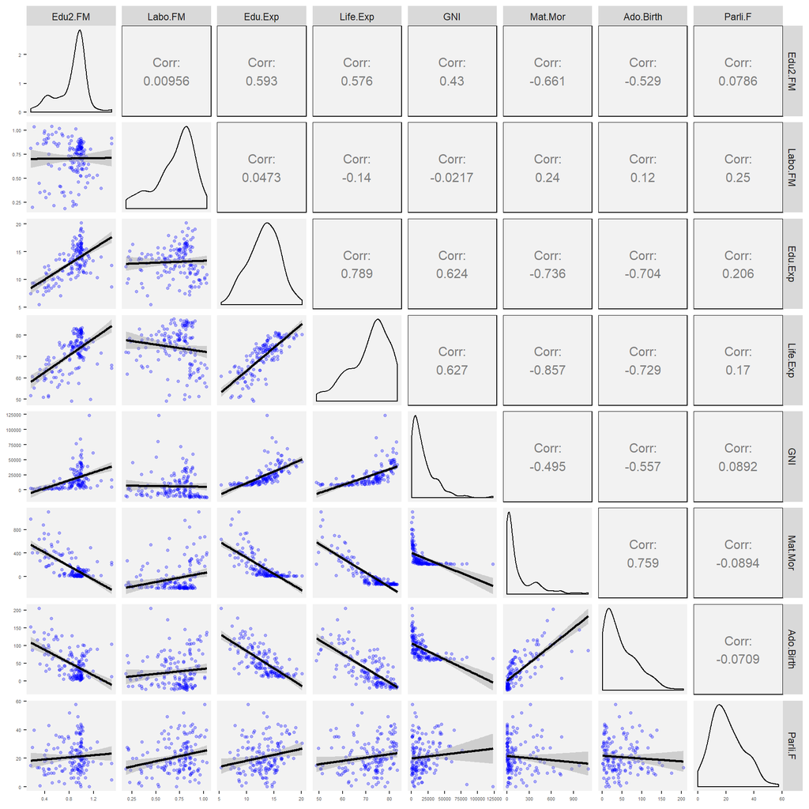

```r
library("GGally")
human <- read.table("http://s3.amazonaws.com/assets.datacamp.com/production/course_2218/datasets/human2.txt",sep  =",", header = T)
human = transform(human, GNI = as.numeric(GNI))
human = transform(human, Mat.Mor = as.numeric(Mat.Mor))


lowerFn <- function(data, mapping, ...) {
  p <- ggplot(data = data, mapping = mapping) +
    geom_point(color = 'blue', alpha=0.3, size=1) +
    geom_smooth(color = 'black', method='lm', size=1,...)
  p
}

g <- ggpairs(
  data = human,
  lower = list(
    continuous =  wrap(lowerFn) #wrap("smooth", alpha = 0.3, color = "blue", lwd=1)
  ),
  upper = list(continuous = wrap("cor", size = 4))
)
g <- g + theme(
  axis.text = element_text(size = 4),
  axis.title = element_text(size = 4),
  legend.background = element_rect(fill = "white"),
  panel.grid.major = element_line(colour = NA),
  panel.grid.minor = element_blank(),
  panel.background = element_rect(fill = "grey95")
)
print(g, bottomHeightProportion = 0.5, leftWidthProportion = .5)
```

### Data interpretation

**Correlations:**

For the sake of clarity I chose one attribute which clearly correlates with other data variables and therefore explains the data well: Ado.Birth

**The adolescent birth rate** is the annual number of live births to adolescent women per 1,000 adolescent women. The adolescent birth rate is also referred to as the age-specific fertility rate for women aged 15-19

- Edu2.FM: Strong negative correlation (-0.53) - countries, where women have children at very young age do not participate in education process (at all).
- Edu.exp: Strong negative correlation (-0.70) - the expected years of schooling is very low if there is high adolescent birth rate. Children (males, females) are not participating in education process, because they reproduce quickly after puberty.
- Life.exp: Strong negative correlation (-0.73) - expected individual lifespan decreases as adolescent birth rate increases. There are many issues related - having children without stable incomes and education does not predict good starting point for offspring.
- GNI: trong negative correlation (-0.56) - GNI (country incomes) decrease while Ado.Birth increases: no education - no incomes.
- Mat.Mor (def. The people of a society share a standard dignity through high morals making the moral fabric a keystone; keeping the arch of society and the morals it holds high-together. https://www.collinsdictionary.com/submission/8889/Moral+fabric) - positive correlation, adolescent birth rate increases Mat.Mor (does not make sense, I guess we should think that as Mat.Mor increases the moral of the country decreases)

Next we will perform PCA-analysis for the HDI-dataset. We will be solving the components that capture most of the variability in the data.

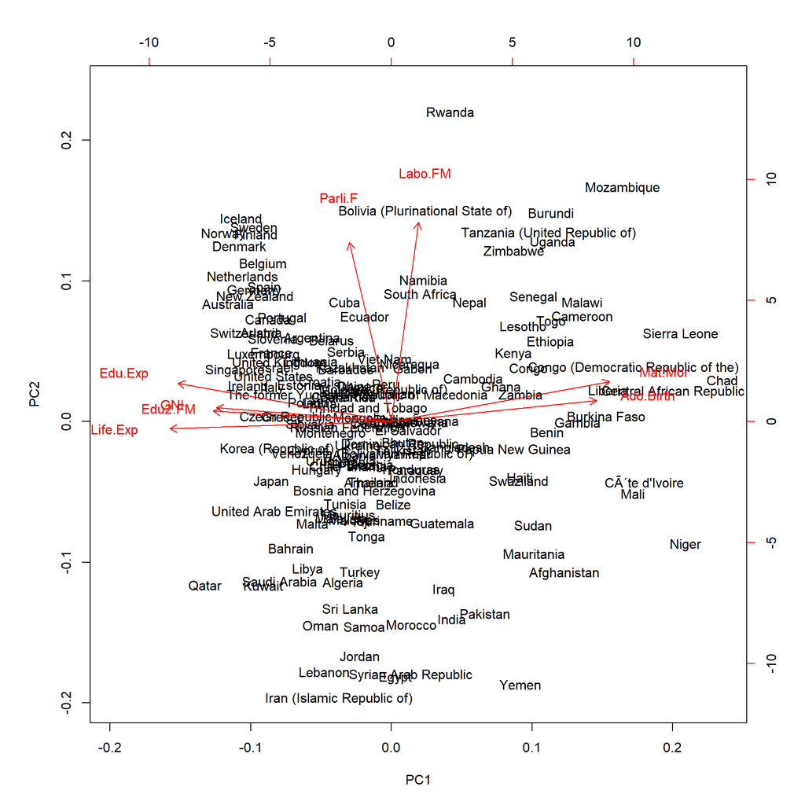

```r
human <- read.table("http://s3.amazonaws.com/assets.datacamp.com/production/course_2218/datasets/human2.txt",sep  =",", header = T)

human = transform(human, GNI = as.numeric(GNI))
human = transform(human, Mat.Mor = as.numeric(Mat.Mor))

# perform principal component analysis (with the SVD method)
#pca_human <- prcomp(human)


pca_human <- prcomp(human, scale=T)

biplot(pca_human)
```

```r
# draw a biplot of the principal component representation and the original variables
#biplot(pca_human, choices = 1:2)
#biplot(pca_human, expand=10, xlim=c(-0.30, 0.0), ylim=c(-0.1, 0.1))
```